# Hospitalizations for ambulatory care-sensitive conditions in Ecuador, 2000–2024: the analysis step by step

From the INEC microdata to the tables and maps of the article

Martínez-Abarca AL, Henríquez-Trujillo MC, Bonilla JE, Henríquez-Trujillo AR

02 November 2026

# 1 How to use this document

This document reproduces the whole study, from the raw INEC files to the tables and maps of the article. Each section explains one step in a few sentences, runs the code and shows the result, so the analysis can be followed, checked and explained.

To run it:

1. Open the file in RStudio and set the paths in the `params` block at the top. The defaults are the folders used by the authors (`C:/Datasets/ecuador`).
2. Set `build_cache: true` the first time, so that `inectab` reads the 25 SPSS files and builds its cache.
3. Click **Knit**. The first run takes 15–25 minutes; slow steps save their result in `out_dir` and are reused later.

The numbers obtained here are the ones in the article. The repository https://github.com/rhenriquezitg/acsc_ecuador contains the same analysis as a single script (`acsc_ecuador_analysis.R`) and an independent audit (`acsc_ecuador_audit.R`).

**What the document produces.** Every table and figure of the article and its supplement:

| Output | Section |
| --- | --- |
| Table 1 | Steps 5 and 6 |
| Table 2, Figure 1, Supplementary Table S4, Figures S1 and S2 | Step 7 |
| Table 3, Supplementary Tables S5 and S6 (segmented regression), Figure S4 | Step 8 |
| Supplementary Tables S1 and S3, Figure S5 | Step 6 |
| Supplementary Tables S2, S7 and S8, Figures 2, S3, S6, S7 and S9 | Step 9 |
| Supplementary Table S9, Figure S8 | Step 10 |
| Supplementary Table S6 (sensitivity analyses) and Table S10 | Steps 11 and 5 |

All tables are saved as CSV files and in one Excel workbook, and all figures as TIFF (300 dpi) and PNG files, in `out_dir` (Step 12).

**What you need**

- R 4.2 or later and the packages loaded below.
- The `inectab` package, written by the authors to harmonize the INEC files.
- The INEC hospital discharge files (*Egresos Hospitalarios* / *Camas y Egresos Hospitalarios*), 2000–2024, from https://www.ecuadorencifras.gob.ec, in `data_root/egresos/`.
- The INEC hospital bed files: the historical series `Tabulados_series_ECEH_2024.xlsx` and the bed files for 2000–2003 (`bdd_camas_hosp_<year>_spss.zip`, unzipped into one folder per year).
- The provincial boundaries (ADM1 2024 shapefile).

# 2 Set-up

## 2.1 Packages

```r
pkgs <- c("dplyr", "tidyr", "readr", "readxl", "haven", "foreign", "ggplot2", "patchwork", "sf",
          "spdep", "sandwich", "ggspatial", "ggrepel", "scales", "knitr", "arrow")
missing <- pkgs[!vapply(pkgs, requireNamespace, logical(1), quietly = TRUE)]
if (length(missing)) install.packages(missing)
invisible(lapply(pkgs[pkgs != "arrow"], library, character.only = TRUE))
```

## 2.2 The inectab package

`inectab` reads each annual SPSS file, applies a crosswalk for that year (variable names, category codes, age units and province codes change between years) and writes one standard table to a Parquet cache. It also provides the population denominators and the ICD-10 tools.

```r
if (!requireNamespace("inectab", quietly = TRUE)) {
  install.packages(params$inectab_src, repos = NULL, type = "source")
}
library(inectab)
packageVersion("inectab")
```

```
## [1] '0.3.1'
```

## 2.3 Folders

```r
OUT <- params$out_dir
dir.create(OUT, showWarnings = FALSE, recursive = TRUE)
saved <- function(name) file.path(OUT, paste0(name, ".rds"))
SEED <- 2026     # the same seed is used for every permutation test
```

# 3 Step 1. The hospital discharge records

## 3.1 Build or open the cache

The first time, `build_cache()` harmonizes the 25 files. Afterwards the cache is opened directly; `open_cache()` returns an Arrow dataset, so filters are applied before data are loaded into memory.

```r
if (isTRUE(params$build_cache)) build_cache(params$data_root, params$cache_dir, datasets = "egresos", years = 2000:2024)
ds <- open_cache(params$cache_dir)
cache_manifest(params$cache_dir) |> filter(dataset == "egresos") |>
  select(file_year, n_records, n_log, n_icd_invalid, source_file) |> head()
```

| file_year | n_records | n_log | n_icd_invalid | source_file |
| --- | --- | --- | --- | --- |
| 2000 | 671909 | 1 | 1 | EGR2000.sav |
| 2001 | 681711 | 3 | 3 | EGR2001.sav |
| 2002 | 707825 | 0 | 0 | EGR2002.sav |
| 2003 | 723494 | 2 | 2 | EGR2003.sav |
| 2004 | 763643 | 0 | 0 | EGR2004.sav |
| 2005 | 802943 | 0 | 0 | EGR2005.sav |

## 3.2 What one record contains

Each row is one discharge. The variables used in this study are the year and month of discharge (`event_year`, `event_month`), sex, age in years, province of residence (`prov_res`) and of the hospital (`prov_occ`), and the main diagnosis (`icd10`, normalized to four characters without the dot, e.g. `J159`).

```r
ds |> filter(dataset == "egresos", event_year == 2024) |>
  select(event_year, event_month, sex, age_years, prov_res, prov_occ, icd10) |>
  head(5) |> collect()
```

| event_year | event_month | sex | age_years | prov_res | prov_occ | icd10 |
| --- | --- | --- | --- | --- | --- | --- |
| 2024 | 5 | 1 | 0.3333333 | 24 | 24 | U072 |
| 2024 | 1 | 1 | 81.0000000 | 09 | 09 | U071 |
| 2024 | 1 | 2 | 88.0000000 | 09 | 09 | U071 |
| 2024 | 1 | 2 | 82.0000000 | 09 | 09 | U071 |
| 2024 | 2 | 1 | 1.0000000 | 01 | 01 | U072 |

## 3.3 Discharges per year

```r
n_year <- ds |> filter(dataset == "egresos") |> count(event_year) |> collect() |> arrange(event_year)
inec_published <- c(671909, 681711, 707825, 723494, 763643, 802943, 863037, 920047, 983286, 1031957, 1090263,
                    1133556, 1156237, 1178989, 1192749, 1161044, 1128004, 1143765, 1164659, 1195311, 907515,
                    1038235, 1130603, 1170813, 1132667)
n_year |> mutate(inec = inec_published, difference = n - inec) |> knitr::kable(big.mark = ",")
```

| event_year | n | inec | difference |
| --- | --- | --- | --- |
| 2000 | 671909 | 671909 | 0 |
| 2001 | 681711 | 681711 | 0 |
| 2002 | 707825 | 707825 | 0 |
| 2003 | 723494 | 723494 | 0 |
| 2004 | 763643 | 763643 | 0 |
| 2005 | 802943 | 802943 | 0 |
| 2006 | 863037 | 863037 | 0 |
| 2007 | 920047 | 920047 | 0 |
| 2008 | 983286 | 983286 | 0 |
| 2009 | 1031957 | 1031957 | 0 |
| 2010 | 1090263 | 1090263 | 0 |
| 2011 | 1133556 | 1133556 | 0 |
| 2012 | 1156237 | 1156237 | 0 |
| 2013 | 1178989 | 1178989 | 0 |
| 2014 | 1192750 | 1192749 | 1 |
| 2015 | 1161043 | 1161044 | -1 |
| 2016 | 1128004 | 1128004 | 0 |
| 2017 | 1143765 | 1143765 | 0 |
| 2018 | 1164659 | 1164659 | 0 |
| 2019 | 1195311 | 1195311 | 0 |
| 2020 | 907515 | 907515 | 0 |
| 2021 | 1038235 | 1038235 | 0 |
| 2022 | 1130603 | 1130603 | 0 |
| 2023 | 1170813 | 1170813 | 0 |
| 2024 | 1132667 | 1132667 | 0 |

# 4 Step 2. Defining ambulatory care-sensitive conditions

## 4.1 The Brazilian list

We use the 20 groups of Alfradique et al. (2009), the list adopted by the Pan American Health Organization. Each group is defined by ICD-10 codes and assigned to one of four categories.

```r
GROUPS <- tibble::tribble(
  ~group, ~name,                                       ~icd10,                                                       ~category,
   1L, "Anemia",                                        "D50",                                                        "Other acute",
   2L, "Angina pectoris",                               "I20",                                                        "Chronic",
   3L, "Asthma",                                        "J45-J46",                                                    "Chronic",
   4L, "Nutritional deficiencies",                      "E40-E46, E50-E64",                                           "Other acute",
   5L, "Diabetes mellitus",                             "E10-E14",                                                    "Chronic",
   6L, "Female pelvic inflammatory disease",            "N70-N73, N75-N76",                                           "Other acute",
   7L, "Cerebrovascular diseases",                      "I63-I67, I69, G45-G46",                                      "Chronic",
   8L, "Lower respiratory tract diseases",              "J20-J21, J40-J44, J47",                                      "Chronic",
   9L, "Immunization-preventable diseases",             "A17.0, A19, A33-A37, A95, B05-B06, B16, B26, G00.0",         "Vaccine-preventable",
  10L, "Prenatal and childbirth care conditions",       "A50, O23, P35.0",                                            "Infectious",
  11L, "Epilepsy",                                      "G40-G41",                                                    "Other acute",
  12L, "Infectious gastroenteritis",                    "A00-A09, E86",                                               "Infectious",
  13L, "Hypertension",                                  "I10-I11",                                                    "Chronic",
  14L, "Ear, nose and throat infections",               "H66, J00-J03, J06, J31",                                     "Infectious",
  15L, "Skin and subcutaneous infections",              "A46, L01-L04, L08",                                          "Infectious",
  16L, "Kidney and urinary tract infections",           "N10-N12, N30, N34, N39.0",                                   "Infectious",
  17L, "Heart failure",                                 "I50, J81",                                                   "Chronic",
  18L, "Bacterial pneumonia",                           "J13-J14, J15.3-J15.4, J15.8-J15.9, J18.1",                   "Vaccine-preventable",
  19L, "Gastrointestinal ulcer",                        "K25-K28, K92.0-K92.2",                                       "Other acute",
  20L, "Other avoidable conditions",                    "A15-A16, A17.1-A17.9, A18, A51-A53, B50-B54, B77, I00-I02",  "Vaccine-preventable")
GROUPS$label <- sprintf("%02d %s", GROUPS$group, GROUPS$name)
CATEGORIES <- c("Chronic", "Infectious", "Vaccine-preventable", "Other acute")
knitr::kable(GROUPS[, c("group", "name", "icd10", "category")])
```

| group | name | icd10 | category |
| --- | --- | --- | --- |
| 1 | Anemia | D50 | Other acute |
| 2 | Angina pectoris | I20 | Chronic |
| 3 | Asthma | J45-J46 | Chronic |
| 4 | Nutritional deficiencies | E40-E46, E50-E64 | Other acute |
| 5 | Diabetes mellitus | E10-E14 | Chronic |
| 6 | Female pelvic inflammatory disease | N70-N73, N75-N76 | Other acute |
| 7 | Cerebrovascular diseases | I63-I67, I69, G45-G46 | Chronic |
| 8 | Lower respiratory tract diseases | J20-J21, J40-J44, J47 | Chronic |
| 9 | Immunization-preventable diseases | A17.0, A19, A33-A37, A95, B05-B06, B16, B26, G00.0 | Vaccine-preventable |
| 10 | Prenatal and childbirth care conditions | A50, O23, P35.0 | Infectious |
| 11 | Epilepsy | G40-G41 | Other acute |
| 12 | Infectious gastroenteritis | A00-A09, E86 | Infectious |
| 13 | Hypertension | I10-I11 | Chronic |
| 14 | Ear, nose and throat infections | H66, J00-J03, J06, J31 | Infectious |
| 15 | Skin and subcutaneous infections | A46, L01-L04, L08 | Infectious |
| 16 | Kidney and urinary tract infections | N10-N12, N30, N34, N39.0 | Infectious |
| 17 | Heart failure | I50, J81 | Chronic |
| 18 | Bacterial pneumonia | J13-J14, J15.3-J15.4, J15.8-J15.9, J18.1 | Vaccine-preventable |
| 19 | Gastrointestinal ulcer | K25-K28, K92.0-K92.2 | Other acute |
| 20 | Other avoidable conditions | A15-A16, A17.1-A17.9, A18, A51-A53, B50-B54, B77, I00-I02 | Vaccine-preventable |

## 4.2 How a code is matched

`icd_match()` reads a specification such as `"J13-J14, J15.3-J15.4"`. A three-character code (`J13`) includes all its subcategories; a four-character code (`J15.3`) only itself.

```r
codes <- c("J13", "J139", "J153", "J155", "J159", "J18", "J181", "J189")
data.frame(code = codes, bacterial_pneumonia = icd_match(codes, GROUPS$icd10[18]))
```

| code | bacterial_pneumonia |
| --- | --- |
| J13 | TRUE |
| J139 | TRUE |
| J153 | TRUE |
| J155 | FALSE |
| J159 | TRUE |
| J18 | FALSE |
| J181 | TRUE |
| J189 | FALSE |

Note `J18`: a record coded only with the three-character category J18 cannot be classified, because only J18.1 belongs to the list. These records (237 in 25 years) are counted as non-ACSC and listed in the log.

## 4.3 A classification function

Each distinct code is matched once against the 20 groups; the result is a lookup table. A code that matched two groups would stop the analysis (it never happens). Deliveries (O80–O84) are flagged as group 99 to report them separately; all other diagnoses are group 0.

```r
classify_codes <- function(codes) {
  codes <- unique(codes[!is.na(codes)])
  hit <- vapply(GROUPS$icd10, function(s) icd_match(codes, s), logical(length(codes)))
  if (any(rowSums(hit) > 1)) stop("A code matches two groups")
  stats::setNames(ifelse(rowSums(hit) == 0, 0L, GROUPS$group[max.col(hit, ties.method = "first")]), codes)
}
partial <- c("A17", "G00", "J15", "J18", "K92", "N39", "P35")   # categories only partly in the list
```

# 5 Step 3. From 25 million records to analysis tables

Rates need counts by year, province, sex, single year of age and group. We read one year at a time, apply the 2024 provincial boundaries (Santo Domingo de los Tsáchilas and Santa Elena were created in 2007; earlier records are reassigned by canton of residence), classify the diagnosis and count. We keep three tables:

- `annual`: year × province (residence and hospital) × sex × age × group;
- `monthly`: year × month × age × group, for the interrupted time series;
- `icd`: the ACSC records by ICD-10 code, to describe the leading diagnoses.

```r
if (file.exists(saved("aggregates"))) {
  agg <- readRDS(saved("aggregates"))
} else {
  agg <- list(annual = list(), monthly = list(), icd = list(), log = list())
  for (y in 2000:2024) {
    d <- ds |> filter(dataset == "egresos", event_year == y) |>
      select(event_year, event_month, sex, age_years, prov_res, cant_res, prov_occ, cant_occ, icd10) |> collect()
    d <- apply_geo_scheme(d, "dpa_2024")
    lk <- classify_codes(d$icd10)
    d$group <- unname(lk[d$icd10]); d$group[is.na(d$group)] <- 0L
    d$group[d$group == 0L & icd_match(d$icd10, "O80-O84")] <- 99L
    d$age <- as.integer(pmin(floor(d$age_years), 100))
    for (g in c("res", "occ")) {
      agg$annual[[length(agg$annual) + 1]] <- d |>
        transmute(geo = g, year = event_year, province = .data[[paste0("prov_", g)]], sex, age, group) |>
        count(geo, year, province, sex, age, group)
    }
    agg$monthly[[y - 1999]] <- d |> count(year = event_year, month = event_month, age, group)
    agg$icd[[y - 1999]] <- d |> filter(group %in% 1:20) |> count(year = event_year, province = prov_res, sex, age, group, icd10)
    agg$log[[y - 1999]] <- tibble(year = y,
      partial_code = sum(nchar(d$icd10) == 3 & d$icd10 %in% partial, na.rm = TRUE),
      missing_age = sum(is.na(d$age)), unknown_sex = sum(!d$sex %in% c("1", "2")),
      outside_24_provinces = sum(is.na(d$prov_res) | !d$prov_res %in% sprintf("%02d", 1:24)),
      missing_month = sum(is.na(d$event_month)))
    message(y, ": ", nrow(d), " discharges")
  }
  agg <- lapply(agg, bind_rows)
  saveRDS(agg, saved("aggregates"))
}
annual <- agg$annual; monthly <- agg$monthly; icd <- agg$icd
agg$log |> summarise(across(-year, sum)) |> knitr::kable(big.mark = ",")
```

| partial_code | missing_age | unknown_sex | outside_24_provinces | missing_month |
| --- | --- | --- | --- | --- |
| 237 | 7337 | 12 | 39270 | 0 |

The log above gives the numbers reported in the Methods: 237 partial codes, 7,337 discharges with missing age, 12 with unknown sex and 39,270 residents abroad or in non-delimited zones. These records are counted in totals and left out of rates.

```r
PROVS <- sprintf("%02d", 1:24)
res <- annual |> filter(geo == "res") |>
  mutate(acsc = group %in% 1:20, category = GROUPS$category[match(group, GROUPS$group)])
usable <- function(d) d |> filter(!is.na(age), sex %in% c("1", "2"), province %in% PROVS)
PER <- c("2000–2007", "2008–2014", "2015–2019", "2020–2024")
period_of <- function(y) as.character(cut(y, c(1999, 2007, 2014, 2019, 2024), labels = PER))
```

# 6 Step 4. Population denominators and the standard population

`inec_population()` returns the INEC projections (revision 2024) by year, province, sex and single year of age, already in 2024 boundaries. The standard population for age standardization is Ecuador’s projected population in 2022; the WHO world standard is used in a sensitivity analysis.

```r
pop <- inec_population() |> filter(year %in% 2000:2024) |> rename(province = prov)
pop |> group_by(year) |> summarise(population = sum(pop)) |> filter(year %in% c(2000, 2011, 2024))
```

| year | population |
| --- | --- |
| 2000 | 12480574 |
| 2011 | 15160587 |
| 2024 | 17966573 |

```r
std_ec <- standard_population("ecuador_2022")
std_who <- standard_population("who")
```

We use 18 five-year age groups, the last one open (85+). The weights are the shares of the standard population in each group.

```r
band <- function(age) pmin(age %/% 5, 17)
band_lab <- c(paste0(seq(0, 80, 5), "–", seq(4, 84, 5)), "85+")
weights_of <- function(s) { w <- tapply(s$weight, band(s$age), sum); w / sum(w) }
W <- weights_of(std_ec); W_who <- weights_of(std_who)
data.frame(age_group = band_lab, ecuador_2022 = round(W, 4), who = round(W_who, 4)) |> head(6)
```

|  | age_group | ecuador_2022 | who |
| --- | --- | --- | --- |
| 0 | 0–4 | 0.0809 | 0.0886 |
| 1 | 5–9 | 0.0899 | 0.0869 |
| 2 | 10–14 | 0.0917 | 0.0860 |
| 3 | 15–19 | 0.0887 | 0.0847 |
| 4 | 20–24 | 0.0871 | 0.0822 |
| 5 | 25–29 | 0.0861 | 0.0793 |

# 7 Step 5. Description of the hospitalizations (Table 1)

```r
ann <- res |> group_by(year) |>
  summarise(acsc = sum(n[acsc]), all = sum(n), deliveries = sum(n[group == 99]), residents = sum(n[province %in% PROVS])) |>
  left_join(pop |> group_by(year) |> summarise(pop = sum(pop)), by = "year") |>
  mutate(share = 100 * acsc / all, per_1000 = 1000 * residents / pop)
tab1 <- ann |> mutate(period = period_of(year)) |> group_by(period) |>
  summarise(ACSC = sum(acsc), all = sum(all), `per 1,000/year` = 1000 * sum(residents) / sum(pop)) |>
  bind_rows(ann |> summarise(period = "2000–2024", ACSC = sum(acsc), all = sum(all), `per 1,000/year` = 1000 * sum(residents) / sum(pop))) |>
  mutate(`ACSC, % of all` = 100 * ACSC / all)
knitr::kable(tab1, digits = 1, format.args = list(big.mark = ","))
```

| period | ACSC | all | per 1,000/year | ACSC, % of all |
| --- | --- | --- | --- | --- |
| 2000–2007 | 1,027,659 | 6,134,609 | 57.6 | 16.8 |
| 2008–2014 | 1,192,764 | 7,767,038 | 73.0 | 15.4 |
| 2015–2019 | 870,189 | 5,792,782 | 68.9 | 15.0 |
| 2020–2024 | 701,948 | 5,379,833 | 60.6 | 13.0 |
| 2000–2024 | 3,792,560 | 25,074,262 | 65.0 | 15.1 |

Of 25,074,262 discharges, 3,792,560 (15.1%) were ACSC. The distribution by category and group:

```r
res |> filter(acsc) |> group_by(category) |> summarise(n = sum(n)) |> mutate(pct = 100 * n / sum(n)) |> arrange(-n)
```

| category | n | pct |
| --- | --- | --- |
| Infectious | 2030784 | 53.546523 |
| Chronic | 1155578 | 30.469604 |
| Other acute | 364161 | 9.601984 |
| Vaccine-preventable | 242037 | 6.381890 |

```r
res |> filter(acsc) |> group_by(group) |> summarise(n = sum(n)) |> mutate(pct = 100 * n / sum(n)) |>
  left_join(GROUPS[, c("group", "name")], by = "group") |> arrange(-n) |> head(4)
```

| group | n | pct | name |
| --- | --- | --- | --- |
| 12 | 990268 | 26.110806 | Infectious gastroenteritis |
| 16 | 453185 | 11.949317 | Kidney and urinary tract infections |
| 5 | 357721 | 9.432178 | Diabetes mellitus |
| 10 | 253630 | 6.687567 | Prenatal and childbirth care conditions |

## 7.1 Composition of ACSC hospitalizations by period

The rest of Table 1 describes who was hospitalized: the percentage of ACSC hospitalizations by sex, age group, condition category and region of residence, in each period.

```r
REGION <- c("Sierra", "Sierra", "Sierra", "Sierra", "Sierra", "Sierra", "Costa", "Costa", "Costa", "Sierra", "Sierra", "Costa",
            "Costa", "Amazonía", "Amazonía", "Amazonía", "Sierra", "Sierra", "Amazonía", "Galápagos", "Amazonía", "Amazonía",
            "Costa", "Costa")
h <- res |> filter(acsc) |> mutate(period = period_of(year),
  sex_l = c("1" = "Men", "2" = "Women")[sex],
  age_g = cut(age, c(-1, 4, 14, 64, 200), labels = c("0–4", "5–14", "15–64", "65+")),
  region = ifelse(province %in% PROVS, REGION[match(province, PROVS)], "Abroad or non-delimited zone"))
composition <- function(var) {
  by_p <- h |> group_by(period, value = .data[[var]]) |> summarise(n = sum(n)) |> group_by(period) |> mutate(pct = 100 * n / sum(n))
  tot <- h |> group_by(value = .data[[var]]) |> summarise(n = sum(n)) |> mutate(pct = 100 * n / sum(n), period = "2000–2024")
  bind_rows(by_p, tot) |> select(-n) |> pivot_wider(names_from = period, values_from = pct) |> mutate(variable = var, .before = 1)
}
table1_composition <- bind_rows(lapply(c("sex_l", "age_g", "category", "region"), composition)) |> filter(!is.na(value))
knitr::kable(table1_composition, digits = 1)
```

| variable | value | 2000–2007 | 2008–2014 | 2015–2019 | 2020–2024 | 2000–2024 |
| --- | --- | --- | --- | --- | --- | --- |
| sex_l | Men | 44.5 | 42.3 | 42.1 | 42.9 | 43.0 |
| sex_l | Women | 55.5 | 57.7 | 57.9 | 57.1 | 57.0 |
| age_g | 0–4 | 23.7 | 21.5 | 20.7 | 17.3 | 21.1 |
| age_g | 5–14 | 9.0 | 9.6 | 10.1 | 9.5 | 9.5 |
| age_g | 15–64 | 47.5 | 46.3 | 44.1 | 44.5 | 45.8 |
| age_g | 65+ | 19.8 | 22.6 | 25.2 | 28.6 | 23.6 |
| category | Chronic | 28.3 | 32.0 | 29.8 | 32.1 | 30.5 |
| category | Infectious | 55.4 | 55.2 | 53.0 | 48.7 | 53.5 |
| category | Other acute | 8.3 | 8.6 | 10.2 | 12.4 | 9.6 |
| category | Vaccine-preventable | 8.1 | 4.2 | 7.0 | 6.8 | 6.4 |
| region | Abroad or non-delimited zone | 0.4 | 0.2 | 0.1 | 0.1 | 0.2 |
| region | Amazonía | 6.3 | 6.6 | 7.3 | 7.0 | 6.7 |
| region | Costa | 52.9 | 52.1 | 50.2 | 48.6 | 51.3 |
| region | Galápagos | 0.1 | 0.2 | 0.2 | 0.2 | 0.2 |
| region | Sierra | 40.3 | 40.8 | 42.2 | 44.1 | 41.6 |

## 7.2 Annual series (Supplementary Table S10)

```r
tableS10 <- ann |> select(year, all, acsc, share, per_1000)
knitr::kable(tableS10, digits = 1, format.args = list(big.mark = ","))
```

| year | all | acsc | share | per_1000 |
| --- | --- | --- | --- | --- |
| 2,000 | 671,909 | 114,535 | 17.0 | 53.7 |
| 2,001 | 681,711 | 116,551 | 17.1 | 53.5 |
| 2,002 | 707,825 | 116,102 | 16.4 | 54.6 |
| 2,003 | 723,494 | 119,130 | 16.5 | 54.9 |
| 2,004 | 763,643 | 125,918 | 16.5 | 57.1 |
| 2,005 | 802,943 | 135,170 | 16.8 | 58.9 |
| 2,006 | 863,037 | 145,257 | 16.8 | 62.2 |
| 2,007 | 920,047 | 154,996 | 16.8 | 65.1 |
| 2,008 | 983,286 | 158,654 | 16.1 | 68.4 |
| 2,009 | 1,031,957 | 160,948 | 15.6 | 70.5 |
| 2,010 | 1,090,263 | 171,702 | 15.7 | 73.1 |
| 2,011 | 1,133,556 | 169,399 | 14.9 | 74.6 |
| 2,012 | 1,156,237 | 173,842 | 15.0 | 74.8 |
| 2,013 | 1,178,989 | 177,947 | 15.1 | 74.9 |
| 2,014 | 1,192,750 | 180,272 | 15.1 | 74.5 |
| 2,015 | 1,161,043 | 172,076 | 14.8 | 71.3 |
| 2,016 | 1,128,004 | 175,704 | 15.6 | 68.2 |
| 2,017 | 1,143,765 | 172,692 | 15.1 | 68.1 |
| 2,018 | 1,164,659 | 170,959 | 14.7 | 68.1 |
| 2,019 | 1,195,311 | 178,758 | 15.0 | 68.7 |
| 2,020 | 907,515 | 103,335 | 11.4 | 51.7 |
| 2,021 | 1,038,235 | 119,045 | 11.5 | 58.9 |
| 2,022 | 1,130,603 | 152,492 | 13.5 | 63.8 |
| 2,023 | 1,170,813 | 164,501 | 14.1 | 65.6 |
| 2,024 | 1,132,667 | 162,575 | 14.4 | 63.0 |

# 8 Step 6. Age-standardized rates

## 8.1 The calculation, by hand, for one year

Direct standardization applies the age-specific rates of the study population to the standard population: ASR = Σ wᵢ · (dᵢ / Nᵢ) × 100,000, where dᵢ are hospitalizations, Nᵢ the population and wᵢ the standard weight of age group *i*. The confidence interval uses the gamma method of Fay and Feuer (1997), which is accurate when counts are small.

```r
h24 <- res |> filter(year == 2024, acsc) |> usable() |> group_by(b = band(age)) |> summarise(d = sum(n))
p24 <- pop |> filter(year == 2024) |> group_by(b = band(age)) |> summarise(N = sum(pop))
by_hand <- h24 |> left_join(p24, by = "b") |> mutate(rate = d / N * 1e5, w = W[b + 1], contribution = w * rate)
knitr::kable(head(by_hand, 5), digits = 4)
```

| b | d | N | rate | w | contribution |
| --- | --- | --- | --- | --- | --- |
| 0 | 27926 | 1363497 | 2048.1160 | 0.08091395 | 165.72116 |
| 1 | 10739 | 1535181 | 699.5266 | 0.08991882 | 62.90061 |
| 2 | 5806 | 1626647 | 356.9305 | 0.09170462 | 32.73218 |
| 3 | 6547 | 1581266 | 414.0353 | 0.08873041 | 36.73753 |
| 4 | 7919 | 1527137 | 518.5520 | 0.08714484 | 45.18913 |

```r
sum(by_hand$contribution)     # age-standardized rate per 100,000, 2024
```

```
## [1] 897.1662
```

## 8.2 A function for any subset

```r
asr_of <- function(cnt, pp, w = W) {
  d <- tapply(cnt$n, factor(band(cnt$age), 0:17), sum); d[is.na(d)] <- 0
  N <- tapply(pp$pop, factor(band(pp$age), 0:17), sum)
  asr <- sum(w * d / N) * 1e5
  v <- sum((w / N)^2 * d) * 1e10; wm <- max(w / N) * 1e5          # Fay-Feuer gamma limits
  tibble(n = sum(d), asr = asr, se = sqrt(v),
         lcl = if (v > 0) qgamma(0.025, asr^2 / v, scale = v / asr) else 0,
         ucl = qgamma(0.975, (asr + wm)^2 / (v + wm^2), scale = (v + wm^2) / (asr + wm)))
}
U <- usable(res)
rate_series <- function(sel = function(d) d$acsc, sex = NULL, w = W) {
  bind_rows(lapply(2000:2024, function(y) {
    cn <- U[U$year == y & sel(U), ]; pp <- pop[pop$year == y, ]
    if (!is.null(sex)) { cn <- cn[cn$sex == sex, ]; pp <- pp[pp$sex == sex, ] }
    asr_of(cn, pp, w) |> mutate(year = y, .before = 1)
  }))
}
nat <- rate_series()
nat |> filter(year %in% c(2000, 2010, 2011, 2024))
```

| year | n | asr | se | lcl | ucl |
| --- | --- | --- | --- | --- | --- |
| 2000 | 114085 | 1016.6072 | 3.158980 | 1010.4251 | 1022.8225 |
| 2010 | 171197 | 1195.8640 | 2.953305 | 1190.0825 | 1201.6686 |
| 2011 | 168929 | 1160.4094 | 2.874973 | 1154.7813 | 1166.0599 |
| 2024 | 162492 | 897.1662 | 2.228250 | 892.8042 | 901.5447 |

The rate was 1,016.6 per 100,000 in 2000, peaked at 1,195.9 in 2010 and was 897.2 in 2024.

```r
men <- rate_series(sex = "1"); women <- rate_series(sex = "2")
cats <- lapply(setNames(CATEGORIES, CATEGORIES), function(k) rate_series(function(d) d$category %in% k))
grps <- lapply(setNames(1:20, GROUPS$label), function(g) rate_series(function(d) d$group == g))
nat_who <- rate_series(w = W_who)
```

## 8.3 Rates by period (Table 1, last rows)

For a period, the counts and the populations of all its years are added up before standardizing, which gives a rate per 100,000 person-years.

```r
YRS <- setNames(c(lapply(PER, function(p) (2000:2024)[period_of(2000:2024) == p]), list(2000:2024)), c(PER, "2000–2024"))
period_rate <- function(sel = function(d) d$acsc, popsel = function(p) p, w = W) bind_rows(lapply(names(YRS), function(p)
  asr_of(U[U$year %in% YRS[[p]] & sel(U), ], popsel(pop[pop$year %in% YRS[[p]], ]), w) |> mutate(period = p, .before = 1)))
crude <- function(sel_age = function(a) TRUE, sx = c("1", "2")) sapply(names(YRS), function(p) {
  x <- U[U$year %in% YRS[[p]] & U$acsc & U$sex %in% sx & sel_age(U$age), ]
  q <- pop[pop$year %in% YRS[[p]] & pop$sex %in% sx & sel_age(pop$age), ]
  sum(x$n) / sum(q$pop) * 1e5 })
table1_rates <- rbind(
  `Crude rate, all` = crude(), `Crude rate, men` = crude(sx = "1"), `Crude rate, women` = crude(sx = "2"),
  `Crude rate, 0–4` = crude(function(a) a < 5), `Crude rate, 5–14` = crude(function(a) a >= 5 & a < 15),
  `Crude rate, 15–64` = crude(function(a) a >= 15 & a < 65), `Crude rate, 65+` = crude(function(a) a >= 65),
  `Age-standardized rate` = period_rate()$asr, `95% CI, lower` = period_rate()$lcl, `95% CI, upper` = period_rate()$ucl)
knitr::kable(table1_rates, digits = 1)
```

|  | 2000–2007 | 2008–2014 | 2015–2019 | 2020–2024 | 2000–2024 |
| --- | --- | --- | --- | --- | --- |
| Crude rate, all | 963.9 | 1120.6 | 1034.4 | 791.2 | 982.7 |
| Crude rate, men | 860.6 | 952.4 | 874.7 | 682.8 | 848.2 |
| Crude rate, women | 1066.5 | 1287.4 | 1192.8 | 898.2 | 1116.1 |
| Crude rate, 0–4 | 1932.9 | 2252.0 | 2259.6 | 1694.8 | 2048.5 |
| Crude rate, 5–14 | 379.4 | 522.4 | 546.1 | 416.1 | 461.2 |
| Crude rate, 15–64 | 759.5 | 826.5 | 707.3 | 533.7 | 711.9 |
| Crude rate, 65+ | 3712.7 | 4240.0 | 3715.1 | 2897.8 | 3620.1 |
| Age-standardized rate | 1039.5 | 1160.1 | 1035.4 | 788.8 | 1007.0 |
| 95% CI, lower | 1037.4 | 1158.0 | 1033.2 | 786.9 | 1005.9 |
| 95% CI, upper | 1041.6 | 1162.2 | 1037.6 | 790.6 | 1008.0 |

## 8.4 Codes and rates by group (Supplementary Table S1)

```r
tableS1 <- bind_rows(lapply(1:20, function(g) {
  r <- period_rate(function(d) d$group == g)
  tibble(group = g, condition = GROUPS$name[g], icd10 = GROUPS$icd10[g], category = GROUPS$category[g],
         n = sum(res$n[res$group == g]), pct_acsc = 100 * n / sum(res$n[res$acsc]),
         !!!setNames(as.list(r$asr[1:4]), paste("ASR", PER)))
}))
knitr::kable(tableS1, digits = 1, format.args = list(big.mark = ","))
```

| group | condition | icd10 | category | n | pct_acsc | ASR 2000–2007 | ASR 2008–2014 | ASR 2015–2019 | ASR 2020–2024 |
| --- | --- | --- | --- | --- | --- | --- | --- | --- | --- |
| 1 | Anemia | D50 | Other acute | 19,951 | 0.5 | 2.4 | 5.0 | 8.2 | 6.7 |
| 2 | Angina pectoris | I20 | Chronic | 39,306 | 1.0 | 10.6 | 12.1 | 10.7 | 13.7 |
| 3 | Asthma | J45-J46 | Chronic | 70,906 | 1.9 | 22.9 | 20.2 | 14.4 | 11.4 |
| 4 | Nutritional deficiencies | E40-E46, E50-E64 | Other acute | 27,745 | 0.7 | 9.1 | 7.0 | 5.0 | 3.6 |
| 5 | Diabetes mellitus | E10-E14 | Chronic | 357,721 | 9.4 | 100.8 | 138.4 | 108.5 | 83.4 |
| 6 | Female pelvic inflammatory disease | N70-N73, N75-N76 | Other acute | 73,792 | 1.9 | 21.2 | 23.0 | 21.2 | 14.6 |
| 7 | Cerebrovascular diseases | I63-I67, I69, G45-G46 | Chronic | 174,416 | 4.6 | 55.8 | 59.4 | 51.4 | 45.6 |
| 8 | Lower respiratory tract diseases | J20-J21, J40-J44, J47 | Chronic | 214,413 | 5.7 | 49.6 | 70.0 | 64.7 | 40.2 |
| 9 | Immunization-preventable diseases | A17.0, A19, A33-A37, A95, B05-B06, B16, B26, G00.0 | Vaccine-preventable | 11,135 | 0.3 | 3.6 | 2.8 | 2.8 | 1.7 |
| 10 | Prenatal and childbirth care conditions | A50, O23, P35.0 | Infectious | 253,630 | 6.7 | 42.3 | 69.0 | 83.7 | 67.7 |
| 11 | Epilepsy | G40-G41 | Other acute | 80,692 | 2.1 | 12.2 | 19.3 | 26.9 | 25.6 |
| 12 | Infectious gastroenteritis | A00-A09, E86 | Infectious | 990,268 | 26.1 | 304.3 | 290.3 | 204.1 | 128.8 |
| 13 | Hypertension | I10-I11 | Chronic | 178,021 | 4.7 | 71.7 | 73.3 | 41.8 | 29.4 |
| 14 | Ear, nose and throat infections | H66, J00-J03, J06, J31 | Infectious | 103,681 | 2.7 | 22.0 | 29.4 | 28.2 | 19.9 |
| 15 | Skin and subcutaneous infections | A46, L01-L04, L08 | Infectious | 230,020 | 6.1 | 45.8 | 62.6 | 71.9 | 60.9 |
| 16 | Kidney and urinary tract infections | N10-N12, N30, N34, N39.0 | Infectious | 453,185 | 11.9 | 94.0 | 142.4 | 145.3 | 107.5 |
| 17 | Heart failure | I50, J81 | Chronic | 120,795 | 3.2 | 45.3 | 41.5 | 32.1 | 28.5 |
| 18 | Bacterial pneumonia | J13-J14, J15.3-J15.4, J15.8-J15.9, J18.1 | Vaccine-preventable | 125,140 | 3.3 | 15.1 | 23.8 | 53.8 | 40.2 |
| 19 | Gastrointestinal ulcer | K25-K28, K92.0-K92.2 | Other acute | 161,981 | 4.3 | 46.2 | 50.6 | 46.7 | 47.4 |
| 20 | Other avoidable conditions | A15-A16, A17.1-A17.9, A18, A51-A53, B50-B54, B77, I00-I02 | Vaccine-preventable | 105,762 | 2.8 | 64.6 | 20.2 | 13.9 | 12.0 |

## 8.5 Age-specific rates by sex and period (Figure S5)

Age-specific rates are crude rates within 17 five-year age groups (80+ open); they show where the burden lies before any standardization.

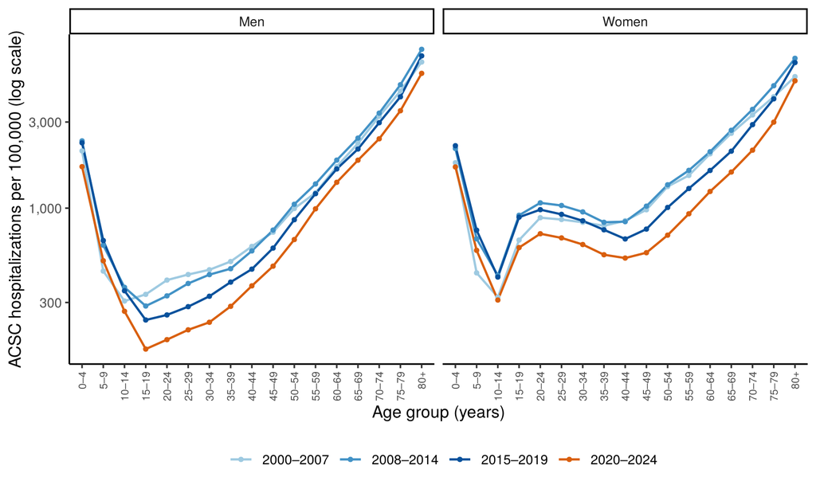

```r
band17 <- function(age) pmin(age %/% 5, 16)
lab17 <- c(paste0(seq(0, 75, 5), "–", seq(4, 79, 5)), "80+")
age_sex_period <- bind_rows(lapply(PER, function(p) {
  x <- U[U$year %in% YRS[[p]] & U$acsc, ] |> group_by(sex, b = band17(age)) |> summarise(n = sum(n))
  q <- pop[pop$year %in% YRS[[p]], ] |> group_by(sex, b = band17(age)) |> summarise(N = sum(pop))
  left_join(q, x, by = c("sex", "b")) |> mutate(period = p, rate = coalesce(n, 0) / N * 1e5)
})) |> mutate(age_band = factor(lab17[b + 1], lab17), sex = c("1" = "Men", "2" = "Women")[sex])
PCOL <- setNames(c("#9ecae1", "#4292c6", "#08519c", "#d95f0e"), PER)
figS5 <- ggplot(age_sex_period, aes(age_band, rate, colour = period, group = period)) + geom_line(linewidth = 0.7) + geom_point(size = 1) +
  facet_wrap(~ sex) + scale_y_log10(labels = scales::label_comma()) + scale_colour_manual(values = PCOL, name = NULL) +
  labs(x = "Age group (years)", y = "ACSC hospitalizations per 100,000 (log scale)") + theme_classic() +
  theme(axis.text.x = element_text(angle = 90, vjust = 0.5, hjust = 1, size = 7), legend.position = "bottom")
figS5
```

```r
ratio <- age_sex_period |> filter(age_band %in% c("15–19", "20–24", "25–29", "30–34")) |> group_by(age_band, sex) |>
  summarise(rate = sum(n) / sum(N)) |> pivot_wider(names_from = sex, values_from = rate) |> mutate(women_to_men = Women / Men)
ratio
```

| age_band | Men | Women | women_to_men |
| --- | --- | --- | --- |
| 15–19 | 0.0026491 | 0.0077025 | 2.907589 |
| 20–24 | 0.0030066 | 0.0092241 | 3.068001 |
| 25–29 | 0.0033264 | 0.0088248 | 2.652954 |
| 30–34 | 0.0036350 | 0.0081966 | 2.254896 |

Among women aged 15–34, rates were 2.3 to 3.1 times those among men.

## 8.6 Leading diagnoses (Supplementary Table S3)

Codes are grouped to three characters, except for the categories that are only partly in the list (for example J15.9), whose four-character codes are kept.

```r
ref <- icd10_reference()
top_dx <- function(years) {
  icd |> filter(year %in% years, !is.na(age), sex %in% c("1", "2")) |>
    mutate(age_broad = cut(age, c(-1, 14, 64, 200), labels = c("0–14", "15–64", "65+")),
           code = ifelse(substr(icd10, 1, 3) %in% partial, icd10, substr(icd10, 1, 3))) |>
    group_by(age_broad, sex, code) |> summarise(n = sum(n)) |> group_by(age_broad, sex) |>
    mutate(pct = 100 * n / sum(n)) |> slice_max(n, n = 5, with_ties = FALSE) |> mutate(rank = row_number()) |> ungroup() |>
    mutate(sex = c("1" = "Men", "2" = "Women")[sex], label = ref$label[match(code, ref$code)])
}
tableS3 <- top_dx(2000:2024)
knitr::kable(tableS3 |> select(age_broad, sex, rank, code, label, n, pct), digits = 1)
```

| age_broad | sex | rank | code | label | n | pct |
| --- | --- | --- | --- | --- | --- | --- |
| 0–14 | Men | 1 | A09 | Diarrea y gastroenteritis de presunto origen infeccioso | 233232 | 38.7 |
| 0–14 | Men | 2 | J20 | Bronquitis aguda | 33397 | 5.5 |
| 0–14 | Men | 3 | J159 | Neumonía bacteriana, no especificada | 30167 | 5.0 |
| 0–14 | Men | 4 | L02 | Absceso cutáneo, furúnculo y ántrax | 24224 | 4.0 |
| 0–14 | Men | 5 | E86 | Depleción del volumen | 23989 | 4.0 |
| 0–14 | Women | 1 | A09 | Diarrea y gastroenteritis de presunto origen infeccioso | 193703 | 34.6 |
| 0–14 | Women | 2 | N390 | Infección de vías urinarias, sitio no especificado | 60633 | 10.8 |
| 0–14 | Women | 3 | J20 | Bronquitis aguda | 26438 | 4.7 |
| 0–14 | Women | 4 | J159 | Neumonía bacteriana, no especificada | 26154 | 4.7 |
| 0–14 | Women | 5 | E86 | Depleción del volumen | 21466 | 3.8 |
| 15–64 | Men | 1 | A09 | Diarrea y gastroenteritis de presunto origen infeccioso | 76408 | 12.4 |
| 15–64 | Men | 2 | E11 | Diabetes mellitus no insulinodependiente | 46446 | 7.5 |
| 15–64 | Men | 3 | K922 | Hemorragia gastrointestinal, no especificada | 36426 | 5.9 |
| 15–64 | Men | 4 | E14 | Diabetes mellitus, no especificada | 32485 | 5.3 |
| 15–64 | Men | 5 | I10 | Hipertensión esencial (primaria) | 30596 | 5.0 |
| 15–64 | Women | 1 | O23 | Infección de las vías genitourinarias en el embarazo | 245249 | 21.9 |
| 15–64 | Women | 2 | N390 | Infección de vías urinarias, sitio no especificado | 126655 | 11.3 |
| 15–64 | Women | 3 | A09 | Diarrea y gastroenteritis de presunto origen infeccioso | 100706 | 9.0 |
| 15–64 | Women | 4 | E11 | Diabetes mellitus no insulinodependiente | 54385 | 4.9 |
| 15–64 | Women | 5 | N12 | Nefritis tubulointersticial, no especificada como aguda o crónica | 54134 | 4.8 |
| 65+ | Men | 1 | I50 | Insuficiencia cardíaca | 39422 | 9.6 |
| 65+ | Men | 2 | J44 | Otras enfermedades pulmonares obstructivas crónicas | 33438 | 8.2 |
| 65+ | Men | 3 | I10 | Hipertensión esencial (primaria) | 31590 | 7.7 |
| 65+ | Men | 4 | K922 | Hemorragia gastrointestinal, no especificada | 30652 | 7.5 |
| 65+ | Men | 5 | E11 | Diabetes mellitus no insulinodependiente | 30387 | 7.4 |
| 65+ | Women | 1 | I10 | Hipertensión esencial (primaria) | 46803 | 9.7 |
| 65+ | Women | 2 | E11 | Diabetes mellitus no insulinodependiente | 46282 | 9.6 |
| 65+ | Women | 3 | N390 | Infección de vías urinarias, sitio no especificado | 42057 | 8.7 |
| 65+ | Women | 4 | I50 | Insuficiencia cardíaca | 39770 | 8.2 |
| 65+ | Women | 5 | A09 | Diarrea y gastroenteritis de presunto origen infeccioso | 34254 | 7.1 |

# 9 Step 7. Joinpoint regression

## 9.1 The idea

A joinpoint model is a set of straight lines on the log scale, joined at the years where the trend changes. On the log scale, a slope *b* means the rate changes by 100·(e^b − 1)% per year: the annual percentage change (APC). Years with more precise rates count more (weights = 1/variance of the log rate). The average annual percentage change (AAPC) summarizes the whole period.

```r
jp_design <- function(x, knots) { X <- cbind(1, x); for (k in knots) X <- cbind(X, pmax(x - k, 0)); X }
jp_fit <- function(year, rate, se, knots) {
  y <- log(rate); w <- (rate / se)^2; X <- jp_design(year, knots)
  f <- lm.wfit(X, y, w); b <- f$coefficients
  df <- length(y) - ncol(X) - length(knots)               # joinpoints count as parameters (NCI convention)
  V <- sum(w * f$residuals^2) / df * solve(crossprod(X * sqrt(w))); tq <- qt(0.975, df)
  starts <- c(min(year), knots); ends <- c(knots, max(year))
  L <- t(sapply(seq_along(starts), function(j) c(0, 1, rep(1, j - 1), rep(0, length(knots) - j + 1))))
  sl <- drop(L %*% b); se_s <- sqrt(diag(L %*% V %*% t(L)))
  seg <- tibble(start = starts, end = ends, apc = 100 * (exp(sl) - 1), lcl = 100 * (exp(sl - tq * se_s) - 1),
                ucl = 100 * (exp(sl + tq * se_s) - 1), p = 2 * pt(-abs(sl / se_s), df))
  l <- colSums(L * (ends - starts)) / sum(ends - starts); a <- sum(l * b); sa <- sqrt(drop(t(l) %*% V %*% l))
  list(segments = seg, aapc = c(aapc = 100 * (exp(a) - 1), lcl = 100 * (exp(a - tq * sa) - 1), ucl = 100 * (exp(a + tq * sa) - 1),
                                p = 2 * pt(-abs(a / sa), df)),
       fitted = exp(drop(X %*% b)), rss = sum(w * f$residuals^2), year = year,
       parts = list(b = b, V = V, L = L, starts = starts, ends = ends, tq = tq, df = df))
}
# AAPC over any sub-period: the slopes of the segments, weighted by the years each covers
aapc_period <- function(fit, from, to) {
  with(fit$parts, {
    wl <- pmax(0, pmin(ends, to) - pmax(starts, from)); l <- colSums(L * wl) / sum(wl)
    a <- sum(l * b); sa <- sqrt(drop(t(l) %*% V %*% l))
    c(aapc = 100 * (exp(a) - 1), lcl = 100 * (exp(a - tq * sa) - 1), ucl = 100 * (exp(a + tq * sa) - 1), p = 2 * pt(-abs(a / sa), df))
  })
}
```

## 9.2 Where are the joinpoints?

For a given number of joinpoints *k*, every allowed combination of years is tried (at least two observations from each end and between joinpoints) and the one with the smallest weighted residual sum of squares is kept. With one joinpoint, the best year for the national series is 2011:

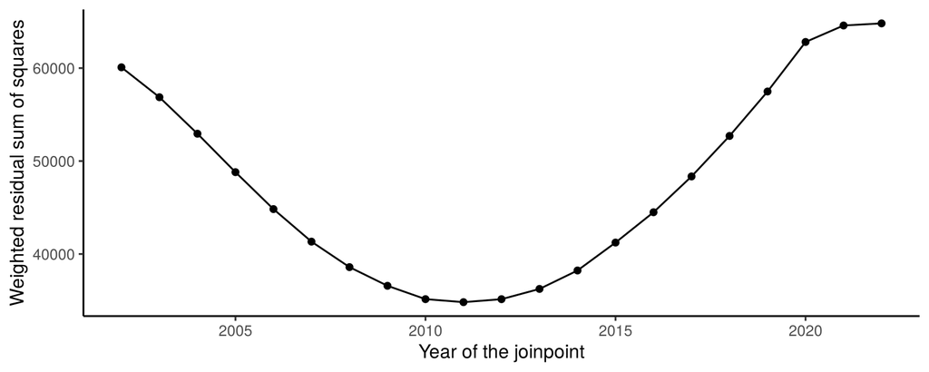

```r
rss1 <- sapply(2002:2022, function(k) jp_fit(nat$year, nat$asr, nat$se, k)$rss)
ggplot(data.frame(year = 2002:2022, rss = rss1), aes(year, rss)) + geom_line() + geom_point() +
  labs(x = "Year of the joinpoint", y = "Weighted residual sum of squares") + theme_classic()
```

## 9.3 How many joinpoints? The permutation test

Kim et al. (2000) compare a model with *a* joinpoints with one with *b* > *a* joinpoints. The residuals of the simpler model are shuffled many times (4,499) to see how often a better fit than the observed one arises by chance. The tests run in sequence, from 0 against the maximum (4 for 25 years), at a Bonferroni-corrected level. To make this feasible, all permuted series are fitted at once with matrix algebra.

```r
jp_candidates <- function(n, k) {
  if (k == 0) return(list(integer()))
  idx <- 3:(n - 2); if (length(idx) < k) return(list())
  Filter(function(p) k == 1 || all(diff(p) >= 3), utils::combn(idx, k, simplify = FALSE))
}
jp_select <- function(year, rate, se, kmax = 4, nperm = params$nperm, alpha = 0.05) {
  set.seed(SEED); y <- log(rate); w <- (rate / se)^2; sw <- sqrt(w); n <- length(y)
  cands <- lapply(0:kmax, function(k) jp_candidates(n, k))
  best <- lapply(cands, function(cl) { r <- sapply(cl, function(p) jp_fit(year, rate, se, year[p])$rss); cl[[which.min(r)]] })
  rss <- sapply(best, function(p) jp_fit(year, rate, se, year[p])$rss)
  Qs <- lapply(cands, function(cl) lapply(cl, function(p) qr.Q(qr(jp_design(year, year[p]) * sw))))
  min_rss <- function(Q, Yw) { out <- rep(Inf, ncol(Yw)); for (q in Q) out <- pmin(out, colSums((Yw - q %*% crossprod(q, Yw))^2)); out }
  a <- 0; b <- kmax; tests <- NULL
  while (a < b) {
    stat <- (rss[a + 1] - rss[b + 1]) / rss[b + 1]
    f0 <- jp_fit(year, rate, se, year[best[[a + 1]]]); fit0 <- log(f0$fitted); r0 <- (y - fit0) * sw
    Yw <- vapply(seq_len(nperm), function(i) fit0 * sw + sample(r0), numeric(n))
    perm <- (min_rss(Qs[[a + 1]], Yw) - min_rss(Qs[[b + 1]], Yw)) / min_rss(Qs[[b + 1]], Yw)
    p <- (sum(perm >= stat) + 1) / (nperm + 1)
    tests <- rbind(tests, data.frame(H0 = a, H1 = b, p = p, level = alpha / kmax))
    if (p < alpha / kmax) a <- a + 1 else b <- b - 1
  }
  list(k = a, knots = year[best[[a + 1]]], tests = tests)
}
sel_nat <- jp_select(nat$year, nat$asr, nat$se)
sel_nat$tests
```

| H0 | H1 | p | level |
| --- | --- | --- | --- |
| 0 | 4 | 0.0015556 | 0.0125 |
| 1 | 4 | 0.0806667 | 0.0125 |
| 1 | 3 | 0.0546667 | 0.0125 |
| 1 | 2 | 0.0820000 | 0.0125 |

```r
jp_nat <- jp_fit(nat$year, nat$asr, nat$se, sel_nat$knots)
jp_nat$segments; round(jp_nat$aapc, 3)
```

| start | end | apc | lcl | ucl | p |
| --- | --- | --- | --- | --- | --- |
| 2000 | 2011 | 2.009988 | 0.3746919 | 3.671926 | 0.0182072 |
| 2011 | 2024 | -3.097727 | -4.2699083 | -1.911192 | 0.0000247 |

```
##   aapc    lcl    ucl      p
## -0.789 -1.442 -0.133  0.021
```

The national rate rose by 2.0% per year until 2011 (95%CI 0.4–3.7) and fell by 3.1% per year afterward (95%CI −4.3 to −1.9); AAPC −0.8%.

## 9.4 Table 2: all series

The same procedure is applied to men, women, the four categories and the ACSC share of all hospitalizations (binomial standard error). Group series use 999 permutations to save time.

```r
if (file.exists(saved("joinpoint"))) {
  JP <- readRDS(saved("joinpoint"))
} else {
  share <- ann |> transmute(year, asr = share, se = 100 * sqrt((acsc / all) * (1 - acsc / all) / all))
  SERIES <- c(list(`All ACSC` = nat, Men = men, Women = women), cats, list(`ACSC share` = share))
  JP <- lapply(SERIES, function(s) { sl <- jp_select(s$year, s$asr, s$se); jp_fit(s$year, s$asr, s$se, sl$knots) })
  JP_groups <- lapply(grps, function(s) { s <- s[s$asr > 0, ]; sl <- jp_select(s$year, s$asr, s$se, nperm = 999); jp_fit(s$year, s$asr, s$se, sl$knots) })
  JP <- c(JP, JP_groups); saveRDS(JP, saved("joinpoint"))
}
table2 <- bind_rows(lapply(names(JP)[1:8], function(k) JP[[k]]$segments |>
  mutate(series = ifelse(row_number() == 1, k, ""), .before = 1) |>
  mutate(AAPC = ifelse(row_number() == 1, sprintf("%.1f (%.1f to %.1f)", JP[[k]]$aapc[1], JP[[k]]$aapc[2], JP[[k]]$aapc[3]), ""))))
knitr::kable(table2, digits = c(0, 0, 0, 1, 1, 1, 3, 0))
```

| series | start | end | apc | lcl | ucl | p | AAPC |
| --- | --- | --- | --- | --- | --- | --- | --- |
| All ACSC | 2000 | 2011 | 2.0 | 0.4 | 3.7 | 0.018 | -0.8 (-1.4 to -0.1) |
|  | 2011 | 2024 | -3.1 | -4.3 | -1.9 | 0.000 |  |
| Men | 2000 | 2010 | 1.7 | -0.2 | 3.6 | 0.070 | -0.8 (-1.5 to -0.2) |
|  | 2010 | 2024 | -2.6 | -3.7 | -1.5 | 0.000 |  |
| Women | 2000 | 2011 | 2.5 | 0.9 | 4.2 | 0.004 | -0.7 (-1.3 to 0.0) |
|  | 2011 | 2024 | -3.3 | -4.4 | -2.1 | 0.000 |  |
| Chronic | 2000 | 2011 | 2.5 | 1.0 | 4.1 | 0.002 | -1.3 (-1.9 to -0.6) |
|  | 2011 | 2024 | -4.4 | -5.4 | -3.3 | 0.000 |  |
| Infectious | 2000 | 2010 | 3.8 | 1.7 | 6.0 | 0.001 | -0.4 (-1.2 to 0.3) |
|  | 2010 | 2024 | -3.4 | -4.6 | -2.1 | 0.000 |  |
| Vaccine-preventable | 2000 | 2010 | -11.7 | -13.9 | -9.4 | 0.000 | -1.8 (-2.8 to -0.7) |
|  | 2010 | 2018 | 10.9 | 7.5 | 14.4 | 0.000 |  |
|  | 2018 | 2021 | -22.6 | -30.3 | -14.1 | 0.000 |  |
|  | 2021 | 2024 | 28.9 | 13.5 | 46.3 | 0.001 |  |
| Other acute | 2000 | 2024 | 0.5 | 0.0 | 1.1 | 0.051 | 0.5 (-0.0 to 1.1) |
| ACSC share | 2000 | 2024 | -1.1 | -1.4 | -0.7 | 0.000 | -1.1 (-1.4 to -0.7) |

## 9.5 All series, with and without 2020–2021 (Supplementary Table S4)

The pandemic years are unusual, so every model is refitted without 2020 and 2021. The table also gives the AAPC for 2000–2007, 2008–2019 and 2015–2024.

```r
share <- ann |> transmute(year, asr = share, se = 100 * sqrt((acsc / all) * (1 - acsc / all) / all))
SERIES <- c(list(`All ACSC` = nat, Men = men, Women = women), cats, list(`ACSC share` = share), grps)
if (file.exists(saved("joinpoint_excl2021"))) {
  JP_x <- readRDS(saved("joinpoint_excl2021"))
} else {
  JP_x <- lapply(names(SERIES), function(k) {
    s <- SERIES[[k]]; s <- s[!s$year %in% 2020:2021 & s$asr > 0, ]
    sl <- jp_select(s$year, s$asr, s$se, nperm = if (k %in% GROUPS$label) 999 else params$nperm); jp_fit(s$year, s$asr, s$se, sl$knots)
  }); names(JP_x) <- names(SERIES); saveRDS(JP_x, saved("joinpoint_excl2021"))
}
seg_text <- function(f) paste(sprintf("%d–%d: %.1f (%.1f to %.1f)", f$segments$start, f$segments$end, f$segments$apc, f$segments$lcl, f$segments$ucl), collapse = "; ")
aapc_text <- function(f, a, b) { x <- aapc_period(f, a, b); sprintf("%.1f (%.1f to %.1f)", x[1], x[2], x[3]) }
tableS4 <- bind_rows(lapply(c("All years", "2020 and 2021 left out"), function(an) {
  L <- if (an == "All years") JP else JP_x
  bind_rows(lapply(names(SERIES), function(k) tibble(analysis = an, series = k, segments = seg_text(L[[k]]),
    `AAPC 2000–2024` = aapc_text(L[[k]], 2000, 2024), `AAPC 2000–2007` = aapc_text(L[[k]], 2000, 2007),
    `AAPC 2008–2019` = aapc_text(L[[k]], 2008, 2019), `AAPC 2015–2024` = aapc_text(L[[k]], 2015, 2024))))
}))
knitr::kable(tableS4 |> filter(series %in% c("All ACSC", "Men", "Women", "ACSC share")))
```

| analysis | series | segments | AAPC 2000–2024 | AAPC 2000–2007 | AAPC 2008–2019 | AAPC 2015–2024 |
| --- | --- | --- | --- | --- | --- | --- |
| All years | All ACSC | 2000–2011: 2.0 (0.4 to 3.7); 2011–2024: -3.1 (-4.3 to -1.9) | -0.8 (-1.4 to -0.1) | 2.0 (0.4 to 3.7) | -1.7 (-2.5 to -1.0) | -3.1 (-4.3 to -1.9) |
| All years | Men | 2000–2010: 1.7 (-0.2 to 3.6); 2010–2024: -2.6 (-3.7 to -1.5) | -0.8 (-1.5 to -0.2) | 1.7 (-0.2 to 3.6) | -1.8 (-2.6 to -1.1) | -2.6 (-3.7 to -1.5) |
| All years | Women | 2000–2011: 2.5 (0.9 to 4.2); 2011–2024: -3.3 (-4.4 to -2.1) | -0.7 (-1.3 to 0.0) | 2.5 (0.9 to 4.2) | -1.7 (-2.4 to -1.0) | -3.3 (-4.4 to -2.1) |
| All years | ACSC share | 2000–2024: -1.1 (-1.4 to -0.7) | -1.1 (-1.4 to -0.7) | -1.1 (-1.4 to -0.7) | -1.1 (-1.4 to -0.7) | -1.1 (-1.4 to -0.7) |
| 2020 and 2021 left out | All ACSC | 2000–2011: 1.9 (1.5 to 2.4); 2011–2024: -2.4 (-2.7 to -2.0) | -0.4 (-0.6 to -0.2) | 1.9 (1.5 to 2.4) | -1.2 (-1.4 to -1.0) | -2.4 (-2.7 to -2.0) |
| 2020 and 2021 left out | Men | 2000–2010: 1.6 (1.1 to 2.0); 2010–2024: -1.9 (-2.2 to -1.6) | -0.5 (-0.7 to -0.3) | 1.6 (1.1 to 2.0) | -1.3 (-1.5 to -1.1) | -1.9 (-2.2 to -1.6) |
| 2020 and 2021 left out | Women | 2000–2011: 2.5 (1.9 to 3.0); 2011–2024: -2.6 (-3.0 to -2.2) | -0.3 (-0.5 to -0.1) | 2.5 (1.9 to 3.0) | -1.2 (-1.5 to -1.0) | -2.6 (-3.0 to -2.2) |
| 2020 and 2021 left out | ACSC share | 2000–2007: -0.2 (-1.0 to 0.7); 2007–2010: -2.4 (-3.8 to -1.1); 2010–2024: -0.6 (-1.0 to -0.3) | -0.7 (-0.9 to -0.5) | -0.2 (-1.0 to 0.7) | -1.0 (-1.2 to -0.7) | -0.6 (-1.0 to -0.3) |

## 9.6 Figures S1 and S2: categories and groups

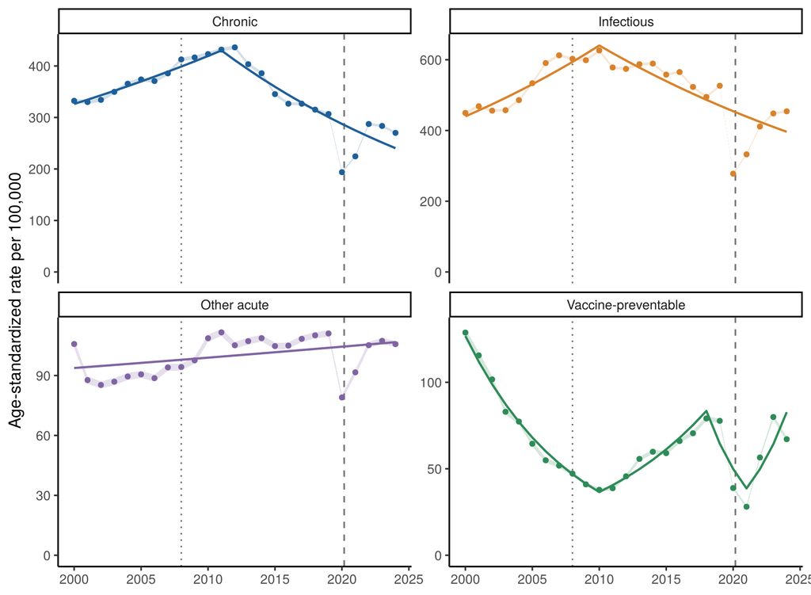

```r
CAT_COL <- setNames(c("#1f5f99", "#d9822b", "#2e8b57", "#8064a2"), CATEGORIES)
REF <- list(geom_vline(xintercept = 2008, linetype = "dotted", colour = "grey45"),
            geom_vline(xintercept = 2020 + 2 / 12, linetype = "dashed", colour = "grey45"))
dS1 <- bind_rows(lapply(CATEGORIES, function(k) mutate(cats[[k]], category = k, fit = JP[[k]]$fitted)))
figS1 <- ggplot(dS1, aes(year, asr, colour = category)) + REF +
  geom_ribbon(aes(ymin = lcl, ymax = ucl, fill = category), alpha = 0.2, colour = NA) + geom_point(size = 1.2) +
  geom_line(aes(y = fit), linewidth = 0.7) + facet_wrap(~ category, scales = "free_y") + expand_limits(y = 0) +
  scale_colour_manual(values = CAT_COL, guide = "none") + scale_fill_manual(values = CAT_COL, guide = "none") +
  labs(x = NULL, y = "Age-standardized rate per 100,000") + theme_classic()
figS1
```

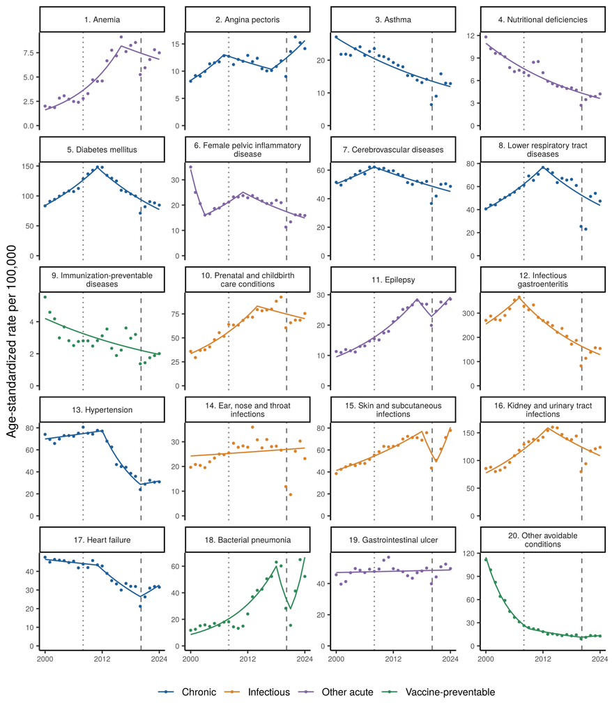

```r
dS2 <- bind_rows(lapply(GROUPS$label, function(k) {
  s <- grps[[k]]; f <- JP[[k]]; s$fit <- f$fitted[match(s$year, f$year)]
  mutate(s, label = factor(sub("^0", "", sub(" ", ". ", k)), sub("^0", "", sub(" ", ". ", GROUPS$label))),
         category = GROUPS$category[as.integer(substr(k, 1, 2))])
}))
figS2 <- ggplot(dS2, aes(year, asr, colour = category)) + REF + geom_point(size = 0.6) + geom_line(aes(y = fit), linewidth = 0.5) +
  facet_wrap(~ label, scales = "free_y", ncol = 4, labeller = label_wrap_gen(30)) + expand_limits(y = 0) +
  scale_colour_manual(values = CAT_COL, name = NULL) + scale_x_continuous(breaks = c(2000, 2012, 2024)) +
  labs(x = NULL, y = "Age-standardized rate per 100,000") + theme_classic() +
  theme(strip.text = element_text(size = 7), axis.text = element_text(size = 6.5), legend.position = "bottom")
figS2
```

## 9.7 Figure 1

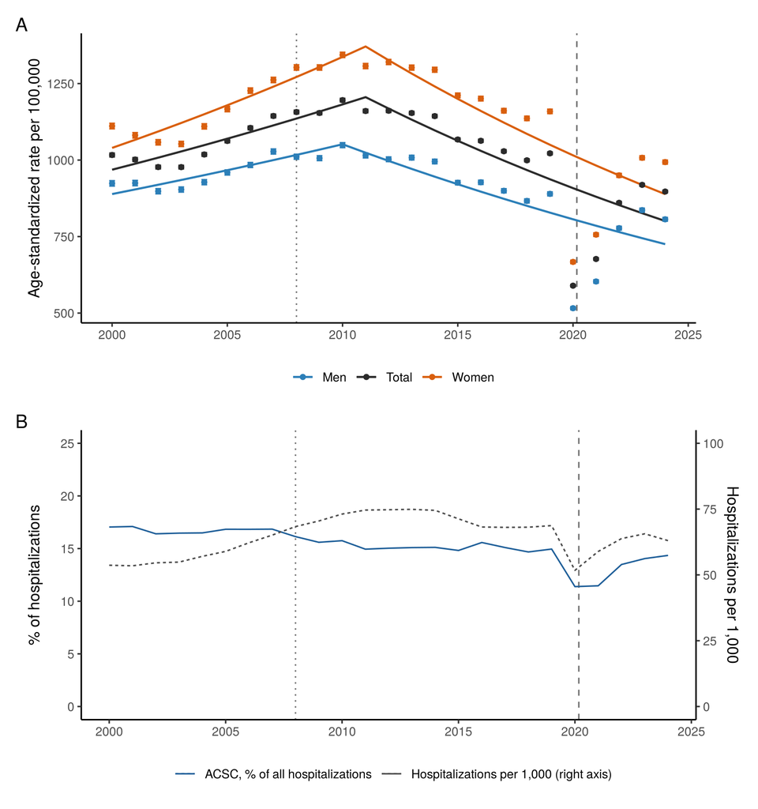

```r
d1 <- bind_rows(mutate(nat, series = "Total", fit = jp_nat$fitted),
                mutate(men, series = "Men", fit = JP$Men$fitted), mutate(women, series = "Women", fit = JP$Women$fitted))
REF <- list(geom_vline(xintercept = 2008, linetype = "dotted", colour = "grey45"),
            geom_vline(xintercept = 2020 + 2 / 12, linetype = "dashed", colour = "grey45"))
pA <- ggplot(d1, aes(year, asr, colour = series)) + REF + geom_line(aes(y = fit), linewidth = 0.7) +
  geom_errorbar(aes(ymin = lcl, ymax = ucl), width = 0.25) + geom_point(size = 1.4) +
  scale_colour_manual(values = c(Total = "#2b2b2b", Men = "#2c7fb8", Women = "#d95f0e"), name = NULL) +
  labs(x = NULL, y = "Age-standardized rate per 100,000") + theme_classic() + theme(legend.position = "bottom")
pB <- ggplot(ann, aes(year)) + REF + geom_line(aes(y = share, colour = "ACSC, % of all hospitalizations")) +
  geom_line(aes(y = per_1000 / 4, colour = "Hospitalizations per 1,000 (right axis)"), linetype = "22") +
  scale_y_continuous("% of hospitalizations", limits = c(0, 25), sec.axis = sec_axis(~ . * 4, name = "Hospitalizations per 1,000")) +
  scale_colour_manual(values = c("#1f5f99", "grey30"), name = NULL) + labs(x = NULL) + theme_classic() + theme(legend.position = "bottom")
fig1 <- pA / pB + plot_annotation(tag_levels = "A")
fig1
```

# 10 Step 8. Segmented regression: the 2008 reform and COVID-19

## 10.1 The model

An interrupted time series compares the trend before an event with the level and trend after it. For monthly counts *y*ₜ:

log E[*y*ₜ] = β₀ + β₁·t + β₂·post + β₃·time since + Fourier terms + log(offset)

- β₂ is the immediate change in level, β₃ the change in trend (×12 for a yearly figure);
- two pairs of sine and cosine terms remove the seasonal cycle;
- quasi-Poisson regression allows for overdispersion, and Newey–West standard errors (lag 12) allow for autocorrelation;
- the offset is the population (for rates) or all hospitalizations (for the ACSC share).

The monthly population is interpolated from the 30 June values.

```r
monthly_pop <- function(years) {
  py <- pop |> filter(year %in% years) |> group_by(year) |> summarise(pop = sum(pop)); x <- py$year + 0.5
  g <- expand.grid(month = 1:12, year = years); tt <- g$year + (g$month - 0.5) / 12
  g$off <- approx(x, py$pop, xout = tt, rule = 2)$y
  s1 <- diff(py$pop[1:2]); s2 <- diff(tail(py$pop, 2))
  g$off[tt < min(x)] <- py$pop[1] + s1 * (tt[tt < min(x)] - x[1]); g$off[tt > max(x)] <- tail(py$pop, 1) + s2 * (tt[tt > max(x)] - max(x))
  g
}
month_series <- function(years, grp) monthly |> filter(year %in% years, group %in% grp) |> group_by(year, month) |> summarise(n = sum(n))
its <- function(years, start, grp, offset = c("pop", "hosp"), excl = 0) {
  offset <- match.arg(offset)
  d <- if (offset == "pop") monthly_pop(years) else rename(month_series(years, c(0:20, 99)), off = n)
  d <- left_join(d, month_series(years, grp), by = c("year", "month")) |> arrange(year, month)
  d$n[is.na(d$n)] <- 0; d$t <- seq_len(nrow(d)); t0 <- which(d$year == start[1] & d$month == start[2])
  d <- d |> mutate(post = as.integer(t >= t0), since = pmax(0, t - t0), s1 = sin(2 * pi * month / 12), c1 = cos(2 * pi * month / 12),
                   s2 = sin(4 * pi * month / 12), c2 = cos(4 * pi * month / 12))
  d$excluded <- d$t >= t0 & d$t < t0 + excl                       # months left out in a sensitivity analysis
  m <- glm(n ~ t + post + since + s1 + c1 + s2 + c2 + offset(log(off)), family = quasipoisson(), data = d[!d$excluded, ])
  V <- NeweyWest(m, lag = 12, prewhite = FALSE, adjust = TRUE); b <- coef(m)
  pct <- function(l) { e <- sum(l * b[names(l)]); s <- sqrt(drop(t(l) %*% V[names(l), names(l)] %*% l))
                       c(est = 100 * (exp(e) - 1), lcl = 100 * (exp(e - 1.96 * s) - 1), ucl = 100 * (exp(e + 1.96 * s) - 1), p = 2 * pnorm(-abs(e / s))) }
  cf <- mutate(d, post = 0, since = 0)
  d$fitted <- predict(m, d, type = "response"); d$counterfactual <- predict(m, cf, type = "response")
  ds <- mutate(d, s1 = 0, c1 = 0, s2 = 0, c2 = 0)                      # deseasonalized: Fourier terms at zero
  d$trend <- predict(m, ds, type = "response"); d$trend_cf <- predict(m, mutate(ds, post = 0, since = 0), type = "response")
  list(effects = rbind(pre_trend = pct(c(t = 12)), level = pct(c(post = 1)), trend_change = pct(c(since = 12)),
                       post_trend = pct(c(t = 12, since = 12))),
       obs_exp = c(observed = sum(d$n[d$post == 1]), expected = sum(d$counterfactual[d$post == 1])), data = d)
}
```

## 10.2 The 2008 reform

```r
reform <- list(acsc = its(2000:2019, c(2008, 1), 1:20), non_acsc = its(2000:2019, c(2008, 1), c(0, 99)),
               share = its(2000:2019, c(2008, 1), 1:20, "hosp"),
               chronic = its(2000:2019, c(2008, 1), GROUPS$group[GROUPS$category == "Chronic"]))
lapply(reform, function(f) round(f$effects, 3))
```

```
## $acsc
##                 est    lcl    ucl     p
## pre_trend     2.795  1.728  3.873 0.000
## level         7.064  1.409 13.035 0.014
## trend_change -3.699 -4.730 -2.657 0.000
## post_trend   -1.008 -1.405 -0.608 0.000
##
## $non_acsc
##                 est    lcl    ucl     p
## pre_trend     2.898  2.302  3.496 0.000
## level        15.421  8.541 22.737 0.000
## trend_change -3.227 -3.987 -2.461 0.000
## post_trend   -0.423 -1.037  0.194 0.179
##
## $share
##                 est    lcl    ucl     p
## pre_trend    -0.080 -0.526  0.367 0.725
## level        -6.026 -8.364 -3.628 0.000
## trend_change -0.432 -0.959  0.098 0.110
## post_trend   -0.512 -0.786 -0.237 0.000
##
## $chronic
##                 est    lcl    ucl p
## pre_trend     3.668  3.181  4.157 0
## level        19.177 10.316 28.750 0
## trend_change -5.232 -6.122 -4.334 0
## post_trend   -1.756 -2.587 -0.918 0
```

```r
round(1 - reform$share$obs_exp["observed"] / reform$share$obs_exp["expected"], 3)
```

```
## observed
##    0.085
```

```r
s2012 <- list(acsc = its(2000:2019, c(2012, 1), 1:20), non_acsc = its(2000:2019, c(2012, 1), c(0, 99)),
              share = its(2000:2019, c(2012, 1), 1:20, "hosp"))
sapply(s2012, function(f) round(f$effects["trend_change", ], 3))
```

```
##       acsc non_acsc share
## est -4.182   -5.107 0.799
## lcl -4.883   -5.702 0.364
## ucl -3.476   -4.508 1.236
## p    0.000    0.000 0.000
```

## 10.3 COVID-19

```r
covid <- list(acsc = its(2012:2024, c(2020, 3), 1:20), non_acsc = its(2012:2024, c(2020, 3), c(0, 99)),
              share = its(2012:2024, c(2020, 3), 1:20, "hosp"))
sapply(covid, function(f) round(f$effects["level", ], 3))
```

```
##        acsc non_acsc   share
## est -44.047  -17.258 -29.703
## lcl -54.879  -27.073 -37.071
## ucl -30.614   -6.122 -21.472
## p     0.000    0.003   0.000
```

```r
covid$acsc$obs_exp
```

```
## observed expected
## 671555.0 818625.4
```

## 10.4 Figure S4

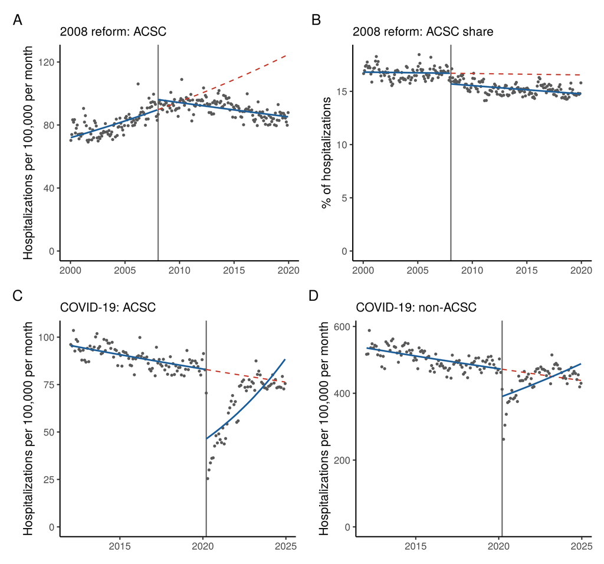

```r
its_plot <- function(f, title, scale = 1, ylab = "Hospitalizations per 100,000 per month") {
  d <- f$data |> mutate(date = as.Date(sprintf("%d-%02d-15", year, month)), rate = n / off * 1e5 * scale,
                        fit = fitted / off * 1e5 * scale, cf = counterfactual / off * 1e5 * scale)
  d <- d |> mutate(trend = trend / off * 1e5 * scale, trend_cf = trend_cf / off * 1e5 * scale)
  ggplot(d, aes(date)) + geom_vline(xintercept = d$date[d$post == 1][1], colour = "grey40") +
    geom_point(aes(y = rate), size = 0.6, colour = "grey35") +
    geom_line(aes(y = trend_cf), data = d[d$post == 1, ], colour = "#c0392b", linetype = "dashed") +
    geom_line(aes(y = trend, group = post), colour = "#1f5f99", linewidth = 0.7) + expand_limits(y = 0) +
    labs(x = NULL, y = ylab, subtitle = title) + theme_classic()
}
figS4 <- (its_plot(reform$acsc, "2008 reform: ACSC") | its_plot(reform$share, "2008 reform: ACSC share", 1e-3, "% of hospitalizations")) /
  (its_plot(covid$acsc, "COVID-19: ACSC") | its_plot(covid$non_acsc, "COVID-19: non-ACSC")) + plot_annotation(tag_levels = "A")
figS4
```

Blue lines show the fitted trend without the seasonal cycle; red dashed lines, the trend projected as if the interruption had not happened.

## 10.5 Table 3: all series

```r
SER3 <- c(list(`All ACSC` = 1:20), lapply(setNames(CATEGORIES, CATEGORIES), function(k) GROUPS$group[GROUPS$category == k]),
          list(`Non-ACSC` = c(0, 99)))
DES <- list(`2008 reform` = list(years = 2000:2019, start = c(2008, 1)), `COVID-19` = list(years = 2012:2024, start = c(2020, 3)))
fmt <- function(x) sprintf("%.1f (%.1f to %.1f)", x["est"], x["lcl"], x["ucl"])
pfm <- function(p) ifelse(p < 0.001, "<0.001", sprintf("%.3f", p))
table3 <- bind_rows(lapply(names(DES), function(dn) bind_rows(lapply(c(names(SER3), "ACSC share"), function(sn) {
  f <- if (sn == "ACSC share") its(DES[[dn]]$years, DES[[dn]]$start, 1:20, "hosp") else its(DES[[dn]]$years, DES[[dn]]$start, SER3[[sn]])
  e <- f$effects
  tibble(design = dn, series = sn, `pre-trend, % per year` = fmt(e["pre_trend", ]), p1 = pfm(e["pre_trend", "p"]),
         `level change, %` = fmt(e["level", ]), p2 = pfm(e["level", "p"]),
         `change in trend, % per year` = fmt(e["trend_change", ]), p3 = pfm(e["trend_change", "p"]),
         `O/E` = round(f$obs_exp[1] / f$obs_exp[2], 2))
}))))
knitr::kable(table3)
```

| design | series | pre-trend, % per year | p1 | level change, % | p2 | change in trend, % per year | p3 | O/E |
| --- | --- | --- | --- | --- | --- | --- | --- | --- |
| 2008 reform | All ACSC | 2.8 (1.7 to 3.9) | <0.001 | 7.1 (1.4 to 13.0) | 0.014 | -3.7 (-4.7 to -2.7) | <0.001 | 0.85 |
| 2008 reform | Chronic | 3.7 (3.2 to 4.2) | <0.001 | 19.2 (10.3 to 28.7) | <0.001 | -5.2 (-6.1 to -4.3) | <0.001 | 0.85 |
| 2008 reform | Infectious | 5.4 (4.1 to 6.7) | <0.001 | 0.8 (-4.8 to 6.8) | 0.777 | -6.8 (-8.1 to -5.6) | <0.001 | 0.64 |
| 2008 reform | Vaccine-preventable | -12.4 (-13.4 to -11.4) | <0.001 | -18.7 (-29.7 to -6.0) | 0.005 | 22.9 (20.3 to 25.7) | <0.001 | 2.69 |
| 2008 reform | Other acute | -0.7 (-3.0 to 1.6) | 0.529 | 16.0 (4.8 to 28.3) | 0.004 | 2.6 (0.2 to 5.0) | 0.035 | 1.36 |
| 2008 reform | Non-ACSC | 2.9 (2.3 to 3.5) | <0.001 | 15.4 (8.5 to 22.7) | <0.001 | -3.2 (-4.0 to -2.5) | <0.001 | 0.94 |
| 2008 reform | ACSC share | -0.1 (-0.5 to 0.4) | 0.725 | -6.0 (-8.4 to -3.6) | <0.001 | -0.4 (-1.0 to 0.1) | 0.110 | 0.92 |
| COVID-19 | All ACSC | -1.7 (-2.3 to -1.2) | <0.001 | -44.0 (-54.9 to -30.6) | <0.001 | 16.5 (9.2 to 24.4) | <0.001 | 0.82 |
| COVID-19 | Chronic | -3.4 (-4.2 to -2.7) | <0.001 | -33.8 (-47.8 to -16.0) | <0.001 | 16.4 (8.8 to 24.6) | <0.001 | 0.96 |
| COVID-19 | Infectious | -2.4 (-3.3 to -1.4) | <0.001 | -48.7 (-59.2 to -35.5) | <0.001 | 18.3 (10.5 to 26.6) | <0.001 | 0.78 |
| COVID-19 | Vaccine-preventable | 7.5 (5.6 to 9.5) | <0.001 | -69.6 (-80.0 to -53.8) | <0.001 | 20.3 (6.9 to 35.3) | 0.002 | 0.50 |
| COVID-19 | Other acute | 1.6 (1.2 to 1.9) | <0.001 | -29.3 (-39.5 to -17.4) | <0.001 | 7.7 (2.6 to 13.0) | 0.003 | 0.85 |
| COVID-19 | Non-ACSC | -1.5 (-2.0 to -1.1) | <0.001 | -17.3 (-27.1 to -6.1) | 0.003 | 6.5 (2.5 to 10.6) | 0.001 | 0.96 |
| COVID-19 | ACSC share | -0.2 (-0.4 to 0.1) | 0.195 | -29.7 (-37.1 to -21.5) | <0.001 | 8.8 (5.3 to 12.4) | <0.001 | 0.87 |

## 10.6 By ACSC group (Supplementary Table S5)

```r
tableS5 <- bind_rows(lapply(names(DES), function(dn) bind_rows(lapply(1:20, function(g) {
  f <- tryCatch(its(DES[[dn]]$years, DES[[dn]]$start, g), error = function(e) NULL)
  if (is.null(f)) return(NULL)
  e <- f$effects
  tibble(design = dn, group = GROUPS$label[g], pre = fmt(e["pre_trend", ]), level = fmt(e["level", ]),
         change = fmt(e["trend_change", ]), post = fmt(e["post_trend", ]), observed = f$obs_exp[1], expected = round(f$obs_exp[2]),
         `O/E` = round(f$obs_exp[1] / f$obs_exp[2], 2))
}))))
knitr::kable(head(tableS5, 6))
```

| design | group | pre | level | change | post | observed | expected | O/E |
| --- | --- | --- | --- | --- | --- | --- | --- | --- |
| 2008 reform | 01 Anemia | 4.4 (0.9 to 8.1) | 27.7 (-0.6 to 64.0) | 5.4 (1.0 to 10.1) | 10.1 (7.5 to 12.7) | 11733 | 6363 | 1.84 |
| 2008 reform | 02 Angina pectoris | 7.9 (6.8 to 9.1) | -6.5 (-13.6 to 1.1) | -6.9 (-8.3 to -5.4) | 0.5 (-0.6 to 1.6) | 18885 | 32470 | 0.58 |
| 2008 reform | 03 Asthma | -1.1 (-3.5 to 1.2) | 12.5 (2.9 to 23.0) | -4.1 (-6.5 to -1.7) | -5.2 (-5.9 to -4.5) | 35565 | 40303 | 0.88 |
| 2008 reform | 04 Nutritional deficiencies | -8.7 (-9.9 to -7.4) | 19.1 (1.3 to 39.9) | 3.8 (1.6 to 6.0) | -5.2 (-6.8 to -3.6) | 12662 | 8739 | 1.45 |
| 2008 reform | 05 Diabetes mellitus | 5.5 (4.8 to 6.3) | 31.7 (18.5 to 46.4) | -6.7 (-8.1 to -5.2) | -1.5 (-2.7 to -0.2) | 205708 | 242756 | 0.85 |
| 2008 reform | 06 Female pelvic inflammatory disease | -6.6 (-11.9 to -1.0) | 50.0 (14.8 to 96.0) | 6.7 (0.7 to 13.1) | -0.3 (-1.0 to 0.3) | 40437 | 18579 | 2.18 |

## 10.7 Sensitivity of the segmented regression

```r
its_sens <- list(
  `COVID-19, window 2015–2024` = its(2015:2024, c(2020, 3), 1:20)$effects["level", ],
  `COVID-19, March–May 2020 left out` = its(2012:2024, c(2020, 3), 1:20, excl = 3)$effects["level", ],
  `Reform, window 2000–2014` = its(2000:2014, c(2008, 1), 1:20)$effects["trend_change", ],
  `Reform, interruption October 2008` = its(2000:2019, c(2008, 10), 1:20)$effects["trend_change", ],
  `Reform, interruption January 2012` = s2012$acsc$effects["trend_change", ],
  `Reform 2012, non-ACSC` = s2012$non_acsc$effects["trend_change", ],
  `Reform 2012, ACSC share` = s2012$share$effects["trend_change", ])
knitr::kable(do.call(rbind, its_sens), digits = 1)
```

|  | est | lcl | ucl | p |
| --- | --- | --- | --- | --- |
| COVID-19, window 2015–2024 | -44.7 | -55.4 | -31.5 | 0 |
| COVID-19, March–May 2020 left out | -42.7 | -54.6 | -27.7 | 0 |
| Reform, window 2000–2014 | -2.4 | -3.4 | -1.3 | 0 |
| Reform, interruption October 2008 | -3.9 | -4.8 | -3.0 | 0 |
| Reform, interruption January 2012 | -4.2 | -4.9 | -3.5 | 0 |
| Reform 2012, non-ACSC | -5.1 | -5.7 | -4.5 | 0 |
| Reform 2012, ACSC share | 0.8 | 0.4 | 1.2 | 0 |

# 11 Step 9. Provinces

## 11.1 Provincial rates and geographic variation

Rates are computed by province of residence for each period. Three indicators summarize the differences: the extremal quotient (highest/lowest rate), the coefficient of variation (CV) and the systematic component of variation (SCV; McPherson et al., 1982). The SCV compares observed with expected counts (indirect standardization by age and sex) and subtracts the part of the variation expected from chance.

```r
PNAME <- c("Azuay", "Bolívar", "Cañar", "Carchi", "Cotopaxi", "Chimborazo", "El Oro", "Esmeraldas", "Guayas", "Imbabura",
           "Loja", "Los Ríos", "Manabí", "Morona Santiago", "Napo", "Pastaza", "Pichincha", "Tungurahua", "Zamora Chinchipe",
           "Galápagos", "Sucumbíos", "Orellana", "Santo Domingo de los Tsáchilas", "Santa Elena")
prov_rates <- function(years) bind_rows(lapply(PROVS, function(p)
  asr_of(U[U$year %in% years & U$province == p & U$acsc, ], pop[pop$year %in% years & pop$province == p, ]) |> mutate(province = p, .before = 1)))
scv_of <- function(years) {
  h <- U[U$year %in% years & U$acsc, ] |> mutate(b = band(age)); pp <- pop |> filter(year %in% years) |> mutate(b = band(age))
  ref <- h |> group_by(b, sex) |> summarise(n = sum(n)) |> left_join(pp |> group_by(b, sex) |> summarise(N = sum(pop)), by = c("b", "sex"))
  E <- pp |> group_by(province, b, sex) |> summarise(N = sum(pop)) |> left_join(ref |> transmute(b, sex, r = n / N), by = c("b", "sex")) |>
    group_by(province) |> summarise(E = sum(N * r))
  O <- h |> group_by(province) |> summarise(O = sum(n)); x <- left_join(E, O, by = "province")
  (mean(((x$O - x$E) / x$E)^2) - mean(1 / x$E)) * 100
}
YRS <- setNames(c(lapply(PER, function(p) (2000:2024)[period_of(2000:2024) == p]), list(2000:2024)), c(PER, "2000–2024"))
PR <- lapply(YRS, prov_rates)
variation <- bind_rows(lapply(names(YRS), function(p) { a <- PR[[p]]$asr
  tibble(period = p, EQ = max(a) / min(a), CV = 100 * sd(a) / mean(a), SCV = scv_of(YRS[[p]])) }))
knitr::kable(variation, digits = 1)
```

| period | EQ | CV | SCV |
| --- | --- | --- | --- |
| 2000–2007 | 3.6 | 38.3 | 16.6 |
| 2008–2014 | 2.5 | 30.0 | 10.8 |
| 2015–2019 | 3.0 | 30.9 | 13.4 |
| 2020–2024 | 2.9 | 29.8 | 12.8 |
| 2000–2024 | 2.7 | 29.4 | 11.1 |

```r
PR$`2000–2024` |> mutate(name = PNAME[as.integer(province)]) |> arrange(-asr) |> select(name, asr, lcl, ucl) |> head(5)
```

| name | asr | lcl | ucl |
| --- | --- | --- | --- |
| Morona Santiago | 2162.404 | 2145.284 | 2179.641 |
| Pastaza | 1920.627 | 1900.445 | 1941.000 |
| Napo | 1626.399 | 1609.287 | 1643.676 |
| Zamora Chinchipe | 1571.758 | 1554.872 | 1588.795 |
| Cañar | 1376.920 | 1367.381 | 1386.515 |

## 11.2 The map

```r
if (nzchar(params$geo_rds) && file.exists(params$geo_rds)) {
  geo <- readRDS(params$geo_rds)
} else {
  sf::sf_use_s2(FALSE)
  s <- sf::st_read(params$shapefile, quiet = TRUE) |> mutate(province = substr(ADM1_PCODE, 3, 4)) |> arrange(province) |> sf::st_make_valid()
  geo <- list(geo = sf::st_transform(sf::st_simplify(sf::st_transform(s, 32717), dTolerance = 250), 4326),
              nb = list(queen = spdep::poly2nb(s, queen = TRUE, snap = 1e-4),
                        knn4 = spdep::knn2nb(spdep::knearneigh(sf::st_coordinates(sf::st_point_on_surface(s)), k = 4, longlat = TRUE))),
              province = s$province)
}
sf::sf_use_s2(FALSE)
g <- geo$geo; gm <- sf::st_geometry(g); i <- g$province == "20"; gm[i] <- gm[i] + c(7, 0)   # Galápagos moved 7° east
sf::st_geometry(g) <- sf::st_set_crs(gm, sf::st_crs(geo$geo))
```

## 11.3 Spatial autocorrelation: Moran’s I and LISA

Moran’s I measures whether neighbouring provinces have similar rates (I > 0) or not. Neighbours share a border (queen contiguity); Galápagos has none. The p-value comes from 999 random reassignments of the rates to provinces. The local version (LISA) asks the same question for each province; with 24 tests, the Benjamini–Hochberg correction controls false positives. An empirical Bayes version shrinks unstable rates of small provinces towards the mean.

```r
lw <- nb2listw(geo$nb$queen, style = "W", zero.policy = TRUE)
moran_by_period <- bind_rows(lapply(names(YRS), function(p) {
  x <- PR[[p]]$asr[match(geo$province, PR[[p]]$province)]
  set.seed(SEED); gm_ <- moran.mc(x, lw, nsim = 999, zero.policy = TRUE)
  h <- U[U$year %in% YRS[[p]] & U$acsc, ] |> group_by(province) |> summarise(n = sum(n))
  pp <- pop[pop$year %in% YRS[[p]], ] |> group_by(province) |> summarise(N = sum(pop))
  d <- left_join(pp, h, by = "province")[match(geo$province, pp$province), ]
  set.seed(SEED); eb <- EBImoran.mc(d$n, d$N, lw, nsim = 999, zero.policy = TRUE)
  tibble(period = p, moran_I = gm_$statistic, p = gm_$p.value, EB_moran_I = eb$statistic, EB_p = eb$p.value)
}))
knitr::kable(moran_by_period, digits = 3)
```

| period | moran_I | p | EB_moran_I | EB_p |
| --- | --- | --- | --- | --- |
| 2000–2007 | 0.083 | 0.103 | 0.077 | 0.132 |
| 2008–2014 | 0.261 | 0.012 | 0.293 | 0.007 |
| 2015–2019 | 0.244 | 0.013 | 0.328 | 0.005 |
| 2020–2024 | 0.303 | 0.006 | 0.357 | 0.003 |
| 2000–2024 | 0.239 | 0.017 | 0.283 | 0.010 |

```r
lisa <- bind_rows(lapply(PER, function(p) {
  x <- PR[[p]]$asr[match(geo$province, PR[[p]]$province)]
  set.seed(SEED); lp <- localmoran_perm(x, lw, nsim = 9999, zero.policy = TRUE)
  pv <- lp[, "Pr(z != E(Ii)) Sim"]; pv[card(geo$nb$queen) == 0] <- NA
  tibble(period = p, province = geo$province, quadrant = as.character(attr(lp, "quadr")$mean), p = pv, p_fdr = p.adjust(pv, "BH"))
}))
lisa |> filter(p < 0.05) |> mutate(name = PNAME[as.integer(province)])
```

| period | province | quadrant | p | p_fdr | name |
| --- | --- | --- | --- | --- | --- |
| 2000–2007 | 22 | Low-High | 0.0362 | 0.6501333 | Orellana |
| 2008–2014 | 10 | Low-Low | 0.0180 | 0.3560400 | Imbabura |
| 2008–2014 | 16 | High-High | 0.0498 | 0.3560400 | Pastaza |
| 2015–2019 | 08 | Low-Low | 0.0294 | 0.3742727 | Esmeraldas |
| 2015–2019 | 14 | High-High | 0.0436 | 0.3742727 | Morona Santiago |
| 2020–2024 | 14 | High-High | 0.0216 | 0.4155333 | Morona Santiago |

Morona Santiago is high-high in 2015–2019 and 2020–2024 and Pastaza in 2008–2014, but none remains significant after correction for multiple testing.

With the four nearest provinces as neighbours, global autocorrelation is not significant in any period:

```r
lw4 <- nb2listw(geo$nb$knn4, style = "W")
sapply(names(YRS), function(p) { x <- PR[[p]]$asr[match(geo$province, PR[[p]]$province)]
  set.seed(SEED); m <- moran.mc(x, lw4, nsim = 999); c(I = unname(m$statistic), p = m$p.value) }) |> round(3)
```

```
##   2000–2007 2008–2014 2015–2019 2020–2024 2000–2024
## I     0.015     0.127     0.100     0.075     0.093
## p     0.253     0.072     0.103     0.139     0.114
```

## 11.4 Provincial trends

For each province, a weighted log-linear regression of the annual rates gives the average change per year in 2000–2011 and 2011–2019.

```r
PY <- bind_rows(lapply(PROVS, function(p) bind_rows(lapply(2000:2024, function(y)
  asr_of(U[U$year == y & U$province == p & U$acsc, ], pop[pop$year == y & pop$province == p, ]) |> mutate(province = p, year = y)))))
wls_trend <- function(d, yrs) { d <- d[d$year %in% yrs, ]; m <- lm(log(asr) ~ year, data = d, weights = (asr / se)^2)
  100 * (exp(c(coef(m)[2], confint(m)[2, ])) - 1) }
trends <- bind_rows(lapply(PROVS, function(p) { d <- PY[PY$province == p, ]; a <- wls_trend(d, 2000:2011); b <- wls_trend(d, 2011:2019)
  tibble(province = p, name = PNAME[as.integer(p)], apc_2000_2011 = a[1], lcl1 = a[2], ucl1 = a[3], apc_2011_2019 = b[1], lcl2 = b[2], ucl2 = b[3]) }))
c(rose_2000_2011 = sum(trends$lcl1 > 0), fell_2011_2019 = sum(trends$ucl2 < 0), rose_2011_2019 = sum(trends$lcl2 > 0))
```

```
## rose_2000_2011 fell_2011_2019 rose_2011_2019
##             15             11              1
```

## 11.5 Supplementary Table S2

```r
lisa_txt <- lisa |> filter(!is.na(p), p < 0.05) |>
  mutate(txt = paste(c("High-High" = "HH", "Low-Low" = "LL", "High-Low" = "HL", "Low-High" = "LH")[quadrant], substr(period, 3, 4), "–", substr(period, 8, 9), sep = "")) |>
  group_by(province) |> summarise(LISA = paste(txt, collapse = "; "))
tableS2 <- bind_rows(lapply(names(YRS), function(p) transmute(PR[[p]], province, period = p, asr))) |>
  pivot_wider(names_from = period, values_from = asr) |>
  left_join(trends |> transmute(province, `APC 2011–2019` = sprintf("%.1f (%.1f to %.1f)", apc_2011_2019, lcl2, ucl2)), by = "province") |>
  left_join(lisa_txt, by = "province") |> mutate(name = PNAME[as.integer(province)], region = REGION[as.integer(province)], .before = 1) |>
  arrange(-`2000–2024`)
knitr::kable(tableS2 |> select(-province), digits = 1)
```

| name | region | 2000–2007 | 2008–2014 | 2015–2019 | 2020–2024 | 2000–2024 | APC 2011–2019 | LISA |
| --- | --- | --- | --- | --- | --- | --- | --- | --- |
| Morona Santiago | Amazonía | 1910.0 | 2457.5 | 2508.0 | 1787.6 | 2162.4 | -1.4 (-3.9 to 1.3) | HH15–19; HH20–24 |
| Pastaza | Amazonía | 2613.5 | 2237.8 | 1790.0 | 1184.2 | 1920.6 | -1.5 (-3.5 to 0.5) | HH08–14 |
| Napo | Amazonía | 2032.1 | 2045.4 | 1418.0 | 1039.6 | 1626.4 | -4.8 (-7.9 to -1.5) | NA |
| Zamora Chinchipe | Amazonía | 1332.1 | 1694.5 | 1757.3 | 1549.2 | 1571.8 | 2.1 (0.7 to 3.5) | NA |
| Cañar | Sierra | 1265.4 | 1560.7 | 1521.1 | 1186.7 | 1376.9 | -0.0 (-1.9 to 1.9) | NA |
| Galápagos | Galápagos | 954.8 | 1384.0 | 1611.9 | 928.7 | 1226.5 | -0.1 (-3.6 to 3.6) | NA |
| El Oro | Costa | 1237.9 | 1382.6 | 1344.6 | 851.1 | 1193.7 | -1.7 (-4.7 to 1.4) | NA |
| Azuay | Sierra | 1189.8 | 1268.8 | 1106.1 | 882.4 | 1121.4 | -2.2 (-3.4 to -0.9) | NA |
| Tungurahua | Sierra | 980.3 | 1337.5 | 1202.8 | 951.5 | 1112.6 | -2.6 (-4.8 to -0.3) | NA |
| Los Ríos | Costa | 1314.5 | 1276.3 | 1134.8 | 717.9 | 1108.2 | -2.9 (-4.8 to -1.0) | NA |
| Santo Domingo de los Tsáchilas | Costa | 1026.1 | 1132.2 | 1087.4 | 972.9 | 1052.6 | 0.2 (-2.5 to 3.1) | NA |
| Chimborazo | Sierra | 948.1 | 1176.5 | 1184.5 | 870.2 | 1038.8 | -0.5 (-1.1 to 0.2) | NA |
| Esmeraldas | Costa | 1267.6 | 1082.2 | 948.2 | 790.4 | 1023.3 | 0.4 (-3.1 to 4.1) | LL15–19 |
| Manabí | Costa | 1001.8 | 1274.7 | 950.9 | 795.3 | 1011.4 | -6.0 (-8.3 to -3.7) | NA |
| Loja | Sierra | 887.5 | 1217.4 | 1064.9 | 853.4 | 1008.0 | -2.7 (-4.9 to -0.4) | NA |
| Sucumbíos | Amazonía | 890.3 | 1066.8 | 1247.1 | 756.5 | 987.5 | 0.5 (-4.0 to 5.2) | NA |
| Cotopaxi | Sierra | 989.3 | 1184.8 | 1107.3 | 646.0 | 980.8 | -2.0 (-3.6 to -0.3) | NA |
| Santa Elena | Costa | 774.6 | 1070.4 | 1217.9 | 752.0 | 948.5 | -0.9 (-4.0 to 2.3) | NA |
| Carchi | Sierra | 934.1 | 972.4 | 961.9 | 876.3 | 941.1 | 0.0 (-1.9 to 2.0) | NA |
| Imbabura | Sierra | 877.6 | 1101.1 | 867.9 | 882.0 | 935.9 | -3.0 (-5.0 to -0.9) | LL08–14 |
| Pichincha | Sierra | 1002.5 | 1003.2 | 964.7 | 809.7 | 927.1 | 0.1 (-0.8 to 1.0) | NA |
| Guayas | Costa | 1001.1 | 1067.0 | 893.7 | 649.4 | 906.9 | -3.0 (-4.7 to -1.4) | NA |
| Bolívar | Sierra | 727.8 | 974.1 | 951.7 | 733.5 | 839.4 | -1.4 (-2.3 to -0.5) | NA |
| Orellana | Amazonía | 726.3 | 1018.3 | 837.0 | 625.7 | 800.3 | -3.6 (-6.1 to -1.1) | LH00–07 |

## 11.6 Annual indicators (Supplementary Tables S7 and S8, Figures S3 and S6)

```r
tableS7 <- PY |> mutate(name = PNAME[as.integer(province)]) |> select(name, year, asr) |> pivot_wider(names_from = year, values_from = asr)
tableS8 <- bind_rows(lapply(2000:2024, function(y) {
  a <- PY$asr[PY$year == y]; names(a) <- PY$province[PY$year == y]
  set.seed(SEED); m <- moran.mc(a[geo$province], lw, nsim = 499, zero.policy = TRUE)
  tibble(year = y, min = min(a), max = max(a), EQ = max(a) / min(a), CV = 100 * sd(a) / mean(a), SCV = scv_of(y),
         moran_I = unname(m$statistic), moran_p = m$p.value)
}))
knitr::kable(tableS8, digits = 3)
```

| year | min | max | EQ | CV | SCV | moran_I | moran_p |
| --- | --- | --- | --- | --- | --- | --- | --- |
| 2000 | 651.666 | 2407.094 | 3.694 | 38.564 | 15.219 | -0.002 | 0.292 |
| 2001 | 648.560 | 2437.472 | 3.758 | 38.103 | 17.044 | -0.005 | 0.310 |
| 2002 | 640.043 | 2143.885 | 3.350 | 40.755 | 19.821 | 0.044 | 0.202 |
| 2003 | 483.593 | 2352.361 | 4.864 | 42.508 | 22.142 | 0.105 | 0.086 |
| 2004 | 658.520 | 2676.570 | 4.065 | 39.637 | 20.134 | 0.115 | 0.050 |
| 2005 | 612.199 | 2788.254 | 4.554 | 39.565 | 17.618 | 0.109 | 0.058 |
| 2006 | 688.074 | 2990.367 | 4.346 | 38.772 | 16.665 | 0.071 | 0.104 |
| 2007 | 747.962 | 2952.304 | 3.947 | 38.207 | 14.626 | 0.101 | 0.062 |
| 2008 | 610.591 | 2605.911 | 4.268 | 36.196 | 13.931 | 0.123 | 0.058 |
| 2009 | 684.918 | 2465.318 | 3.599 | 34.460 | 14.282 | 0.214 | 0.012 |
| 2010 | 885.992 | 2810.538 | 3.172 | 33.645 | 12.512 | 0.255 | 0.010 |
| 2011 | 895.614 | 2243.417 | 2.505 | 24.793 | 6.410 | 0.284 | 0.006 |
| 2012 | 922.463 | 2993.950 | 3.246 | 34.246 | 16.711 | 0.273 | 0.004 |
| 2013 | 887.179 | 2832.649 | 3.193 | 32.669 | 14.018 | 0.240 | 0.002 |
| 2014 | 975.694 | 2528.916 | 2.592 | 29.376 | 10.738 | 0.195 | 0.028 |
| 2015 | 749.158 | 2610.705 | 3.485 | 31.485 | 13.486 | 0.171 | 0.034 |
| 2016 | 837.964 | 2594.603 | 3.096 | 31.960 | 13.190 | 0.184 | 0.030 |
| 2017 | 801.511 | 2605.188 | 3.250 | 32.767 | 14.240 | 0.222 | 0.012 |
| 2018 | 715.904 | 2351.373 | 3.284 | 31.371 | 15.211 | 0.273 | 0.004 |
| 2019 | 819.408 | 2399.361 | 2.928 | 31.010 | 14.392 | 0.325 | 0.002 |
| 2020 | 497.792 | 1556.125 | 3.126 | 35.048 | 20.054 | 0.258 | 0.006 |
| 2021 | 558.706 | 1714.022 | 3.068 | 35.150 | 21.233 | 0.254 | 0.020 |
| 2022 | 630.837 | 1852.304 | 2.936 | 29.235 | 12.659 | 0.271 | 0.010 |
| 2023 | 685.408 | 1921.774 | 2.804 | 28.248 | 9.494 | 0.340 | 0.002 |
| 2024 | 655.805 | 1878.915 | 2.865 | 28.292 | 10.411 | 0.266 | 0.008 |

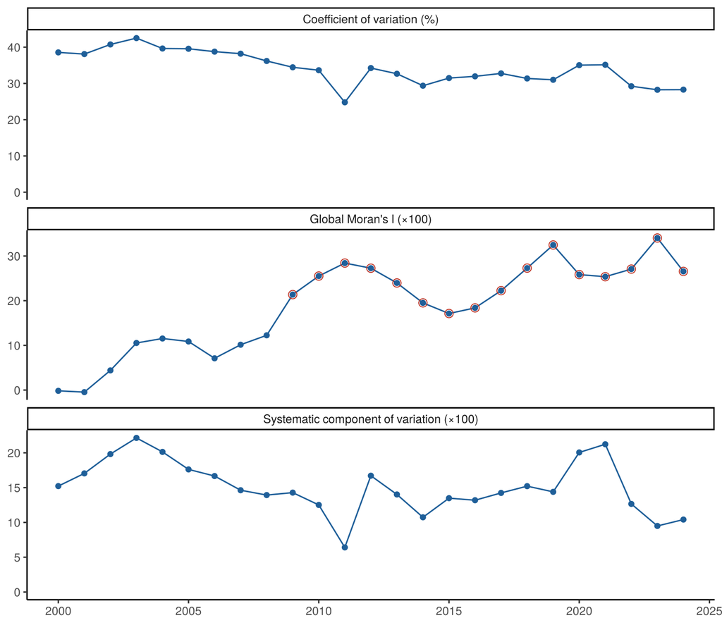

```r
figS3 <- tableS8 |> transmute(year, `Coefficient of variation (%)` = CV, `Systematic component of variation (×100)` = SCV,
                              `Global Moran's I (×100)` = 100 * moran_I, sig = moran_p < 0.05) |>
  pivot_longer(-c(year, sig)) |>
  ggplot(aes(year, value)) + geom_line(colour = "#1f5f99") + geom_point(colour = "#1f5f99") +
  geom_point(data = function(d) d[d$sig & d$name == "Global Moran's I (×100)", ], shape = 21, size = 2.6, colour = "#c0392b") +
  facet_wrap(~ name, ncol = 1, scales = "free_y") + expand_limits(y = 0) + labs(x = NULL, y = NULL) + theme_classic()
figS3
```

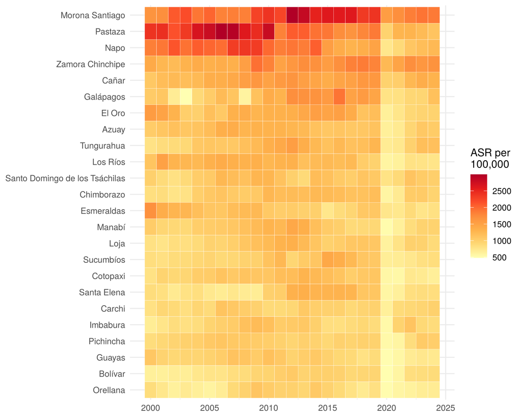

```r
ord <- PR$`2000–2024` |> arrange(asr) |> pull(province)
figS6 <- PY |> mutate(name = factor(PNAME[as.integer(province)], PNAME[as.integer(ord)])) |>
  ggplot(aes(year, name, fill = asr)) + geom_tile(colour = "white") +
  scale_fill_distiller(palette = "YlOrRd", direction = 1, name = "ASR per\n100,000") + labs(x = NULL, y = NULL) + theme_minimal()
figS6
```

## 11.7 Figures S7 and S9: local clusters and reference map

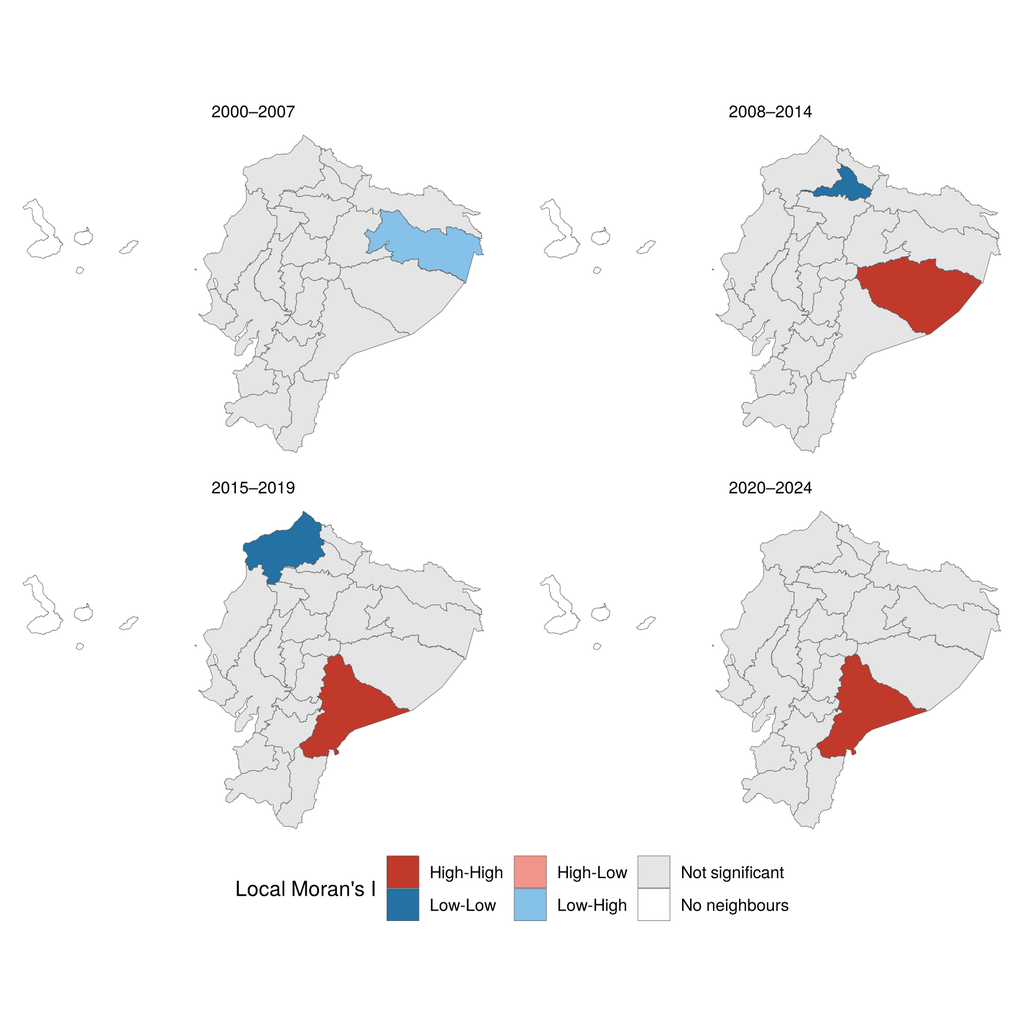

```r
LISA_COL <- c("High-High" = "#c0392b", "Low-Low" = "#2471a3", "High-Low" = "#f1948a", "Low-High" = "#85c1e9",
              "Not significant" = "#e5e5e5", "No neighbours" = "#ffffff")
ml <- merge(g, lisa, by = "province") |>
  mutate(cluster = factor(ifelse(is.na(p), "No neighbours", ifelse(p < 0.05, quadrant, "Not significant")), names(LISA_COL)))
figS7 <- ggplot(ml) + geom_sf(aes(fill = cluster), colour = "grey35", linewidth = 0.12) + facet_wrap(~ period, ncol = 2) +
  scale_fill_manual(values = LISA_COL, drop = FALSE, name = "Local Moran's I") + theme_void() + theme(legend.position = "bottom")
figS7
```

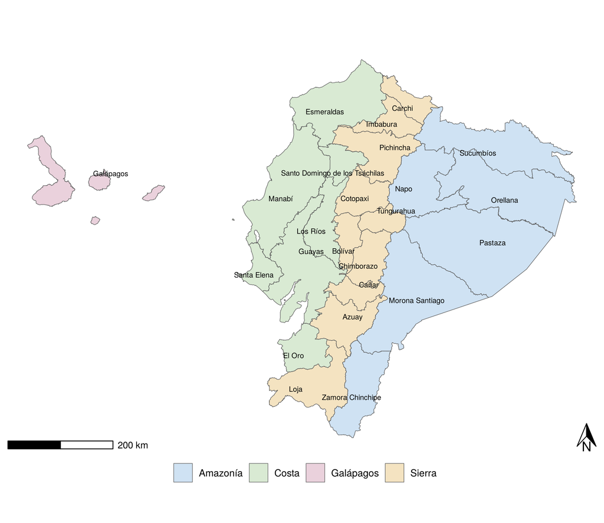

```r
gref <- g |> mutate(name = PNAME[as.integer(province)], region = REGION[as.integer(province)])
figS9 <- ggplot(gref) + geom_sf(aes(fill = region), colour = "grey35", linewidth = 0.2) +
  ggrepel::geom_text_repel(aes(label = name, geometry = geometry), stat = "sf_coordinates", size = 2.3, seed = SEED) +
  scale_fill_manual(values = c(Costa = "#d9ead3", Sierra = "#f4e3c1", Amazonía = "#cfe2f3", Galápagos = "#ead1dc"), name = NULL) +
  ggspatial::annotation_scale(location = "bl") + ggspatial::annotation_north_arrow(location = "br", height = unit(8, "mm"), width = unit(6, "mm")) +
  theme_void() + theme(legend.position = "bottom")
figS9
```

## 11.8 Rates by province of the hospital (sensitivity)

The canton of the hospital is available from 2002, so this analysis covers 2002–2024.

```r
occ <- usable(annual |> filter(geo == "occ") |> mutate(acsc = group %in% 1:20))
occ_rates <- bind_rows(lapply(PROVS, function(p) asr_of(occ[occ$year %in% 2002:2024 & occ$province == p & occ$acsc, ],
                                                        pop[pop$year %in% 2002:2024 & pop$province == p, ]) |> mutate(name = PNAME[as.integer(p)])))
occ_rates |> arrange(-asr) |> select(name, asr) |> head(4)
```

| name | asr |
| --- | --- |
| Morona Santiago | 2042.155 |
| Pastaza | 1989.153 |
| Napo | 1678.692 |
| Zamora Chinchipe | 1273.975 |

## 11.9 Figure 2

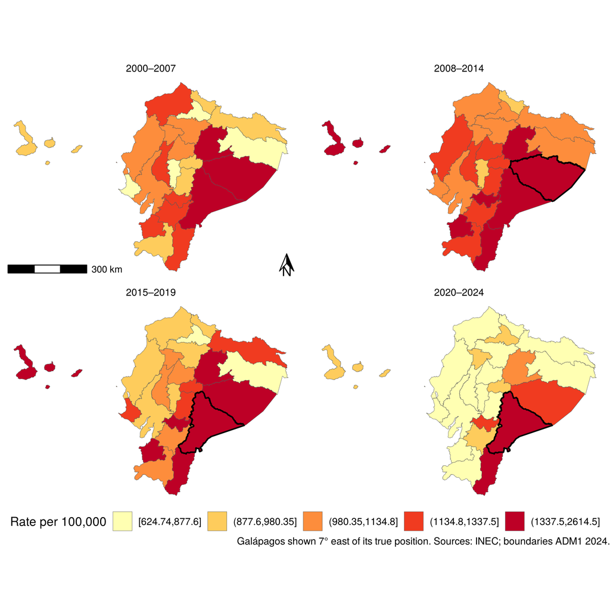

```r
fig2 <- local({
pp4 <- bind_rows(lapply(PER, function(p) mutate(PR[[p]], period = p)))
br <- quantile(pp4$asr, 0:5 / 5); br[c(1, 6)] <- br[c(1, 6)] + c(-1, 1)
mp <- merge(g, pp4, by = "province") |> mutate(q = cut(asr, br, include.lowest = TRUE, dig.lab = 5))
hh <- lisa |> filter(p < 0.05, quadrant == "High-High")
ggplot(mp) + geom_sf(aes(fill = q), colour = "grey35", linewidth = 0.12) +
  geom_sf(data = merge(g, hh, by = "province"), fill = NA, colour = "black", linewidth = 0.6) +
  facet_wrap(~ period, ncol = 2) + scale_fill_brewer(palette = "YlOrRd", name = "Rate per 100,000") +
  ggspatial::annotation_scale(data = data.frame(period = PER[1]), location = "bl", width_hint = 0.3) +
  ggspatial::annotation_north_arrow(data = data.frame(period = PER[1]), location = "br", height = unit(6, "mm"), width = unit(4.5, "mm")) +
  labs(caption = "Galápagos shown 7° east of its true position. Sources: INEC; boundaries ADM1 2024.") +
  theme_void() + theme(legend.position = "bottom")
})
fig2
```

# 12 Step 10. Hospital beds

## 12.1 Reading the bed series

Beds by province come from two INEC sources: the published historical series for 2004–2024 (sheet 1.5.2, available beds; sheet 1.5.3, beds of normal allocation) and the establishment files for 2000–2003, which we add up by province. In those years Santo Domingo de los Tsáchilas and Santa Elena were still part of Pichincha and Guayas; their beds are split with the shares of 2004.

```r
PNAME_UP <- c("AZUAY", "BOLIVAR", "CAÑAR", "CARCHI", "COTOPAXI", "CHIMBORAZO", "EL ORO", "ESMERALDAS", "GUAYAS", "IMBABURA",
              "LOJA", "LOS RIOS", "MANABI", "MORONA SANTIAGO", "NAPO", "PASTAZA", "PICHINCHA", "TUNGURAHUA", "ZAMORA CHINCHIPE",
              "GALAPAGOS", "SUCUMBIOS", "ORELLANA", "SANTO DOMINGO DE LOS TSACHILAS", "SANTA ELENA")   # as written in the INEC sheets
read_series <- function(sheet) {
  x <- readxl::read_excel(params$beds_xlsx, sheet = sheet, col_names = FALSE, .name_repair = "minimal")
  hdr <- which(x[[1]] == "PROVINCIA")[1]; yrs <- as.integer(unlist(x[hdr, -1])); keep <- !is.na(yrs)
  rows <- x[trimws(x[[1]]) %in% PNAME_UP, c(TRUE, keep)]
  tibble(province = sprintf("%02d", match(trimws(rows[[1]]), PNAME_UP)), !!!setNames(lapply(rows[-1], as.numeric), yrs[keep])) |>
    pivot_longer(-province, names_to = "year", values_to = "beds") |> mutate(year = as.integer(year), beds = round(beds))
}
b0424 <- read_series("1.5.2") |> rename(available = beds) |> left_join(read_series("1.5.3") |> rename(normal = beds), by = c("province", "year"))
core <- c("MEDIC", "CIRUG", "GINOB", "PEDIA", "CARDI", "NEUMO", "PSIQU", "TRAUM", "INFEC", "OFTAL", "UROLO", "GASTR", "OTRSE", "SERIN")
read_beds_year <- function(y) {
  if (y == 2000) {
    d <- foreign::read.dbf(file.path(params$beds_raw_dir, "2000", "ech2000w.dbf"), as.is = TRUE)
    names(d) <- c("CODESTAD", "ANIESTAD", "PROUBIES", "CLAESTSA", "TIPESTSA", "ENTESTSA", "SECESTSA", paste0("DOT", core),
                  paste0("DIS", core), "TOTCAMDO", "TOTCAMDI", "DIADISPO", "DIAHOSPI", "FALMEN48", "FALMAS48", "TOTEGRES")
  } else d <- as.data.frame(haven::zap_labels(haven::read_sav(list.files(file.path(params$beds_raw_dir, y), "[.]sav$", recursive = TRUE, full.names = TRUE)[1])))
  tibble(year = y, prov = d$PROUBIES, available = as.numeric(d$TOTCAMDI),
         normal = rowSums(sapply(paste0("DOT", core), function(v) as.numeric(d[[v]]))))
}
raw0003 <- bind_rows(lapply(2000:2003, read_beds_year))
raw0003 |> group_by(year) |> summarise(available = sum(available))      # equals INEC national totals
```

| year | available |
| --- | --- |
| 2000 | 19564 |
| 2001 | 20171 |
| 2002 | 19653 |
| 2003 | 18544 |

```r
s04 <- b0424 |> filter(year == 2004)
sh <- function(child, parent, v) s04[[v]][s04$province == child] / sum(s04[[v]][s04$province %in% c(child, parent)])
b0003 <- bind_rows(lapply(2000:2003, function(y) {
  x <- raw0003 |> filter(year == y, prov %in% sprintf("%02d", 1:22)) |> group_by(province = prov) |>
    summarise(available = sum(available), normal = sum(normal))
  out <- tibble(year = y, province = c(x$province, "23", "24"))
  for (v in c("available", "normal")) {
    val <- setNames(x[[v]], x$province); s23 <- sh("23", "17", v); s24 <- sh("24", "09", v)
    val["23"] <- val["17"] * s23; val["17"] <- val["17"] * (1 - s23)      # Santo Domingo out of Pichincha
    val["24"] <- val["09"] * s24; val["09"] <- val["09"] * (1 - s24)      # Santa Elena out of Guayas
    out[[v]] <- round(unname(val[out$province]))
  }
  out
}))
beds <- bind_rows(b0003, b0424) |> arrange(province, year)
```

## 12.2 Cleaning registration errors

Some provincial values are clearly wrong for a single year or two (Manabí had 3,635 beds in 2008 against about 1,400–1,800 around it; Galápagos had 0 beds in 2003 and 2008). A five-year running median, repeated until it no longer changes, removes such spikes and keeps real changes that last three years or more.

```r
smooth5 <- function(b) { x <- b; repeat { nx <- as.numeric(runmed(x, 5, endrule = "median")); if (all(nx == x)) break; x <- nx }; x }
beds <- beds |> group_by(province) |> mutate(available_s = smooth5(available), normal_s = smooth5(normal)) |> ungroup() |>
  left_join(pop |> group_by(year, province) |> summarise(pop = sum(pop)), by = c("year", "province")) |>
  mutate(b10k = available_s / pop * 1e4, changed = available_s > 1.25 * available | available_s < available / 1.25 | available == 0)
sum(beds$changed)
```

```
## [1] 21
```

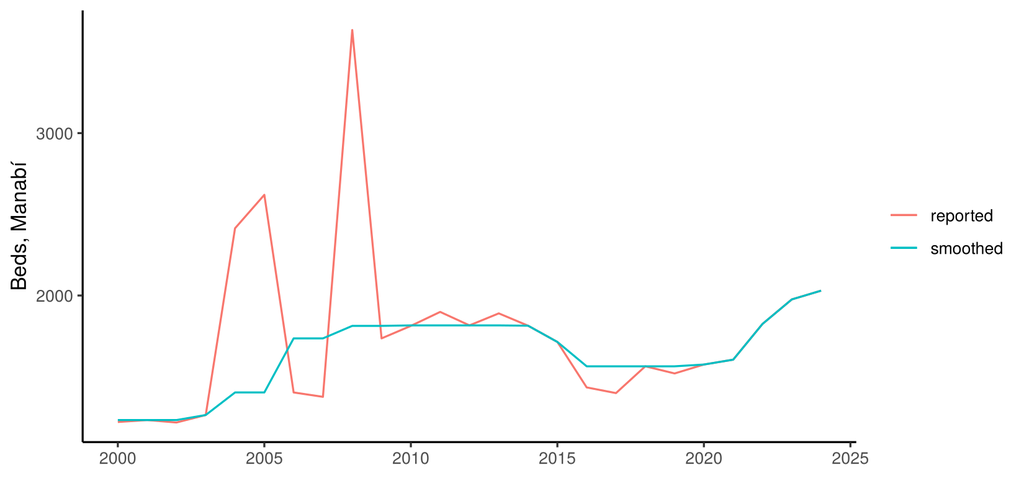

```r
ggplot(filter(beds, province == "13"), aes(year)) + geom_line(aes(y = available, colour = "reported")) +
  geom_line(aes(y = available_s, colour = "smoothed")) + labs(y = "Beds, Manabí", x = NULL, colour = NULL) + theme_classic()
```

## 12.3 Do beds explain ACSC hospitalizations?

Within each province, we ask whether years with more beds per inhabitant had more hospitalizations, after removing everything constant in a province (province fixed effects) and everything common to all provinces in a year (year fixed effects). The outcome is the observed count with the expected count (age-sex standardization) as offset, so the coefficient refers to standardized rates. Standard errors are clustered by province.

```r
panel_of <- function(grp, basis = "res") {
  x <- annual |> filter(geo == basis, group %in% grp) |> usable() |> mutate(b = band(age))
  pp <- pop |> mutate(b = band(age))
  ref <- x |> group_by(b, sex) |> summarise(n = sum(n)) |> left_join(pp |> group_by(b, sex) |> summarise(N = sum(pop)), by = c("b", "sex"))
  pp |> group_by(year, province, b, sex) |> summarise(N = sum(pop)) |> left_join(transmute(ref, b, sex, r = n / N), by = c("b", "sex")) |>
    group_by(year, province) |> summarise(expected = sum(N * r)) |>
    left_join(x |> group_by(year, province) |> summarise(observed = sum(n)), by = c("year", "province")) |>
    mutate(observed = coalesce(observed, 0)) |> left_join(beds, by = c("year", "province"))
}
fe_beds <- function(d, offset = "expected") {
  m <- glm(observed ~ log(b10k) + factor(province) + factor(year) + offset(log(d[[offset]])), family = quasipoisson(), data = d)
  V <- vcovCL(m, cluster = d$province); b <- unname(coef(m)["log(b10k)"]); s <- sqrt(V["log(b10k)", "log(b10k)"])
  c(pct_per_10pct_beds = 100 * (1.1^b - 1), lcl = 100 * (1.1^(b - 1.96 * s) - 1), ucl = 100 * (1.1^(b + 1.96 * s) - 1), beta = unname(b))
}
p_acsc <- panel_of(1:20); p_non <- panel_of(c(0, 99))
p_share <- p_acsc |> left_join(p_non |> select(year, province, other = observed), by = c("year", "province")) |> mutate(all = observed + other)
bed_models <- rbind(ACSC = fe_beds(p_acsc), `Non-ACSC` = fe_beds(p_non), `ACSC share` = fe_beds(p_share, "all"))
round(bed_models, 2)
```

```
##            pct_per_10pct_beds   lcl  ucl  beta
## ACSC                     4.54  3.25 5.84  0.47
## Non-ACSC                 4.84  3.62 6.08  0.50
## ACSC share              -0.38 -1.36 0.62 -0.04
```

Ten percent more beds came with 4.5% more ACSC hospitalizations and 4.8% more other hospitalizations: hospital use in general follows bed supply, and the ACSC share does not.

```r
ch <- p_acsc |> filter(year %in% c(2011, 2024)) |> select(year, province, b10k, observed, expected) |>
  pivot_wider(names_from = year, values_from = c(b10k, observed, expected))
c(attributable_to_beds = 100 * (sum(ch$observed_2024) / sum(ch$observed_2024 * (ch$b10k_2011 / ch$b10k_2024)^bed_models[1, "beta"]) - 1),
  observed_change = 100 * ((sum(ch$observed_2024) / sum(ch$expected_2024)) / (sum(ch$observed_2011) / sum(ch$expected_2011)) - 1))
```

```
## attributable_to_beds      observed_change
##            -5.717753           -22.128776
```

## 12.4 Sensitivity of the bed models (Supplementary Table S9)

```r
fe_beds2 <- function(d, xv = "b10k", offset = "expected", lag = 0) {
  d <- d |> arrange(province, year) |> group_by(province) |> mutate(x = if (lag) dplyr::lag(.data[[xv]], lag) else .data[[xv]]) |> ungroup()
  d <- d[!is.na(d$x) & d$x > 0, ]; d$b10k <- d$x; fe_beds(d, offset)
}
beds <- beds |> mutate(b10k_raw = available / pop * 1e4, b10k_normal = normal_s / pop * 1e4)
p_acsc <- panel_of(1:20); p_non <- panel_of(c(0, 99)); p_occ <- panel_of(1:20, "occ")
p_share <- p_acsc |> left_join(p_non |> select(year, province, other = observed), by = c("year", "province")) |> mutate(all = observed + other)
tableS9 <- rbind(
  `ACSC hospitalization rate` = fe_beds(p_acsc), `Non-ACSC hospitalization rate` = fe_beds(p_non), `ACSC share` = fe_beds(p_share, "all"),
  `ACSC, reported bed counts` = fe_beds2(p_acsc, "b10k_raw"), `ACSC, beds of normal allocation` = fe_beds2(p_acsc, "b10k_normal"),
  `ACSC, beds lagged one year` = fe_beds2(p_acsc, lag = 1), `ACSC, 2020–2021 left out` = fe_beds(p_acsc[!p_acsc$year %in% 2020:2021, ]),
  `ACSC, 2004–2024 only` = fe_beds(p_acsc[p_acsc$year >= 2004, ]),
  `ACSC, split provinces left out 2000–2003` = fe_beds(p_acsc[!(p_acsc$year <= 2003 & p_acsc$province %in% c("09", "17", "23", "24")), ]),
  `ACSC by province of the hospital` = fe_beds(p_occ), `ACSC share, reported bed counts` = fe_beds2(p_share, "b10k_raw", "all"))
knitr::kable(tableS9[, 1:3], digits = 2)
```

|  | pct_per_10pct_beds | lcl | ucl |
| --- | --- | --- | --- |
| ACSC hospitalization rate | 4.54 | 3.25 | 5.84 |
| Non-ACSC hospitalization rate | 4.84 | 3.62 | 6.08 |
| ACSC share | -0.38 | -1.36 | 0.62 |
| ACSC, reported bed counts | 2.73 | 1.35 | 4.13 |
| ACSC, beds of normal allocation | 4.51 | 2.97 | 6.08 |
| ACSC, beds lagged one year | 4.26 | 3.05 | 5.50 |
| ACSC, 2020–2021 left out | 4.48 | 3.14 | 5.84 |
| ACSC, 2004–2024 only | 4.71 | 3.02 | 6.43 |
| ACSC, split provinces left out 2000–2003 | 4.88 | 3.34 | 6.45 |
| ACSC by province of the hospital | 6.22 | 4.78 | 7.69 |
| ACSC share, reported bed counts | -0.12 | -0.89 | 0.65 |

## 12.5 Do beds explain differences between provinces?

Across provinces, the rank correlation between rates and bed density is weak. A regression of the log rate on log bed density explains little of the variation, and Moran’s I of its residuals shows that the spatial pattern remains after allowing for beds.

```r
between <- bind_rows(lapply(names(YRS), function(p) {
  bb <- beds |> filter(year %in% YRS[[p]]) |> group_by(province) |> summarise(b10k = sum(available_s) / sum(pop) * 1e4)
  d <- left_join(PR[[p]], bb, by = "province"); ct <- suppressWarnings(cor.test(d$asr, d$b10k, method = "spearman"))
  f <- lm(log(asr) ~ log(b10k), data = d); r <- residuals(f)[match(geo$province, d$province)]
  set.seed(SEED); mr <- moran.mc(r, lw, nsim = 999, zero.policy = TRUE)
  tibble(period = p, rho = unname(ct$estimate), p = ct$p.value, R2 = summary(f)$r.squared, moran_residuals = unname(mr$statistic), p_moran = mr$p.value)
}))
knitr::kable(between, digits = 3)
```

| period | rho | p | R2 | moran_residuals | p_moran |
| --- | --- | --- | --- | --- | --- |
| 2000–2007 | 0.434 | 0.035 | 0.168 | -0.028 | 0.375 |
| 2008–2014 | 0.303 | 0.149 | 0.054 | 0.215 | 0.023 |
| 2015–2019 | 0.252 | 0.234 | 0.035 | 0.176 | 0.049 |
| 2020–2024 | 0.378 | 0.069 | 0.083 | 0.222 | 0.026 |
| 2000–2024 | 0.319 | 0.129 | 0.060 | 0.163 | 0.061 |

## 12.6 Figure S8

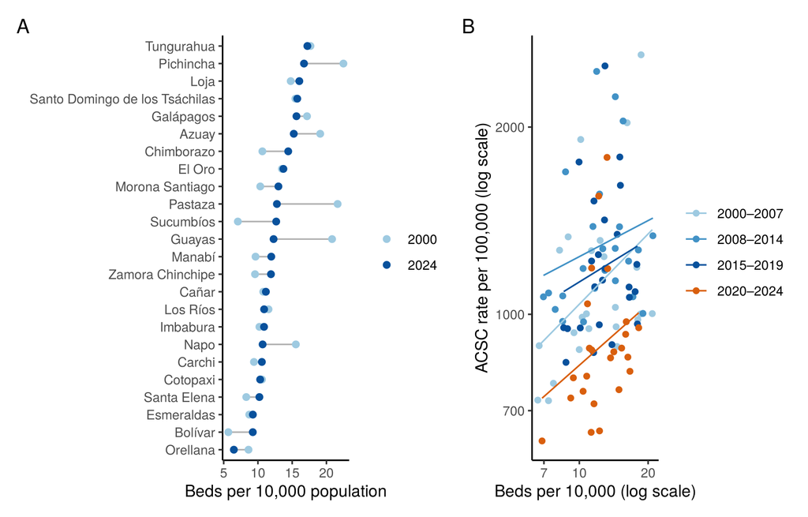

```r
bp <- beds |> filter(year %in% c(2000, 2024)) |> mutate(name = PNAME[as.integer(province)])
bp$name <- factor(bp$name, bp$name[bp$year == 2024][order(bp$b10k[bp$year == 2024])])
s8a <- ggplot(bp, aes(b10k, name)) + geom_line(aes(group = name), colour = "grey70") + geom_point(aes(colour = factor(year)), size = 1.8) +
  scale_colour_manual(values = c("2000" = "#9ecae1", "2024" = "#08519c"), name = NULL) + labs(x = "Beds per 10,000 population", y = NULL) + theme_classic()
pb <- bind_rows(lapply(PER, function(p) {
  bb <- beds |> filter(year %in% YRS[[p]]) |> group_by(province) |> summarise(b10k = sum(available_s) / sum(pop) * 1e4)
  left_join(PR[[p]], bb, by = "province") |> mutate(period = p) }))
s8b <- ggplot(pb, aes(b10k, asr, colour = period)) + geom_point() + geom_smooth(method = "lm", se = FALSE, linewidth = 0.5) +
  scale_x_log10() + scale_y_log10() + scale_colour_manual(values = PCOL, name = NULL) +
  labs(x = "Beds per 10,000 (log scale)", y = "ACSC rate per 100,000 (log scale)") + theme_classic()
figS8 <- s8a + s8b + plot_annotation(tag_levels = "A")
figS8
```

# 13 Step 11. Sensitivity analyses

The article reports several checks. Two examples:

```r
no10 <- rate_series(function(d) d$acsc & d$group != 10)
jp10 <- jp_fit(no10$year, no10$asr, no10$se, jp_select(no10$year, no10$asr, no10$se)$knots)
pooled_sex <- function(sel) sapply(c("2", "1"), function(sx) asr_of(U[sel(U) & U$sex == sx, ], pop[pop$sex == sx, ])$asr)
pr10 <- bind_rows(lapply(PROVS, function(p) asr_of(U[U$province == p & U$acsc & U$group != 10, ], pop[pop$province == p, ]) |> mutate(province = p)))
set.seed(SEED); m10 <- moran.mc(pr10$asr[match(geo$province, pr10$province)], lw, nsim = 999, zero.policy = TRUE)
tableS6 <- tribble(~analysis, ~measure, ~result,
  "Main analysis", "National ASR 2000; 2011; 2024", paste(sprintf("%.1f", nat$asr[nat$year %in% c(2000, 2011, 2024)]), collapse = "; "),
  "WHO world standard", "National ASR 2000; 2011; 2024", paste(sprintf("%.1f", nat_who$asr[nat_who$year %in% c(2000, 2011, 2024)]), collapse = "; "),
  "Group 10 left out", "Joinpoint segments", seg_text(jp10),
  "Main analysis", "Pooled ASR 2000–2024, women; men", paste(sprintf("%.0f", pooled_sex(function(d) d$acsc)), collapse = "; "),
  "Group 10 left out", "Pooled ASR 2000–2024, women; men", paste(sprintf("%.0f", pooled_sex(function(d) d$acsc & d$group != 10)), collapse = "; "),
  "Group 10 left out", "Global Moran's I 2000–2024", sprintf("%.2f (p = %.3f)", m10$statistic, m10$p.value),
  "Province of the hospital, 2002–2024", "Highest provincial ASRs", paste(sprintf("%s %.1f", arrange(occ_rates, -asr)$name[1:4], arrange(occ_rates, -asr)$asr[1:4]), collapse = "; "))
tableS6 <- bind_rows(tableS6, tibble(analysis = names(its_sens), measure = "Segmented regression (level or trend change)",
                                     result = sapply(its_sens, function(x) sprintf("%.1f (%.1f to %.1f)", x[1], x[2], x[3]))))
knitr::kable(tableS6)
```

| analysis | measure | result |
| --- | --- | --- |
| Main analysis | National ASR 2000; 2011; 2024 | 1016.6; 1160.4; 897.2 |
| WHO world standard | National ASR 2000; 2011; 2024 | 1044.0; 1192.4; 917.9 |
| Group 10 left out | Joinpoint segments | 2000–2011: 1.7 (0.0 to 3.4); 2011–2024: -3.3 (-4.5 to -2.1) |
| Main analysis | Pooled ASR 2000–2024, women; men | 1122; 895 |
| Group 10 left out | Pooled ASR 2000–2024, women; men | 993; 894 |
| Group 10 left out | Global Moran’s I 2000–2024 | 0.26 (p = 0.010) |
| Province of the hospital, 2002–2024 | Highest provincial ASRs | Morona Santiago 2042.2; Pastaza 1989.2; Napo 1678.7; Zamora Chinchipe 1274.0 |
| COVID-19, window 2015–2024 | Segmented regression (level or trend change) | -44.7 (-55.4 to -31.5) |
| COVID-19, March–May 2020 left out | Segmented regression (level or trend change) | -42.7 (-54.6 to -27.7) |
| Reform, window 2000–2014 | Segmented regression (level or trend change) | -2.4 (-3.4 to -1.3) |
| Reform, interruption October 2008 | Segmented regression (level or trend change) | -3.9 (-4.8 to -3.0) |
| Reform, interruption January 2012 | Segmented regression (level or trend change) | -4.2 (-4.9 to -3.5) |
| Reform 2012, non-ACSC | Segmented regression (level or trend change) | -5.1 (-5.7 to -4.5) |
| Reform 2012, ACSC share | Segmented regression (level or trend change) | 0.8 (0.4 to 1.2) |

# 14 Step 12. Saving the tables

```r
TABLES <- list(Table1_composition = table1_composition, Table1_rates = tibble::rownames_to_column(as.data.frame(table1_rates), "row"),
               Table2 = table2, Table3 = table3, S1 = tableS1, S2 = tableS2, S3 = tableS3, S4 = tableS4, S5 = tableS5, S6 = tableS6,
               S7 = tableS7, S8 = tableS8, S9 = tibble::rownames_to_column(as.data.frame(tableS9), "model"), S10 = tableS10,
               national_rates = nat, provincial_variation = variation, moran = moran_by_period, lisa = lisa, bed_between = between)
dir.create(file.path(OUT, "tables"), showWarnings = FALSE); dir.create(file.path(OUT, "figures"), showWarnings = FALSE)
for (k in names(TABLES)) readr::write_csv(TABLES[[k]], file.path(OUT, "tables", paste0(k, ".csv")))
writexl::write_xlsx(TABLES, file.path(OUT, "tables", "all_tables.xlsx"))
FIGS <- list(Figure1 = list(fig1, 7, 8), Figure2 = list(fig2, 7.5, 7.7), FigureS1 = list(figS1, 7.5, 5.5), FigureS2 = list(figS2, 7.5, 8.75),
             FigureS3 = list(figS3, 6.5, 6.5), FigureS4 = list(figS4, 7.5, 7), FigureS5 = list(figS5, 7.5, 4.5), FigureS6 = list(figS6, 7.5, 6),
             FigureS7 = list(figS7, 7.5, 7.7), FigureS8 = list(figS8, 7.5, 4.8), FigureS9 = list(figS9, 7, 6.5))
for (k in names(FIGS)) {
  ggsave(file.path(OUT, "figures", paste0(k, ".tif")), FIGS[[k]][[1]], width = FIGS[[k]][[2]], height = FIGS[[k]][[3]], dpi = 300,
         device = ragg::agg_tiff, compression = "lzw", bg = "white")
  ggsave(file.path(OUT, "figures", paste0(k, ".png")), FIGS[[k]][[1]], width = FIGS[[k]][[2]], height = FIGS[[k]][[3]], dpi = 300,
         device = ragg::agg_png, bg = "white")
}
list.files(file.path(OUT, "tables")); list.files(file.path(OUT, "figures"))
```

```
##  [1] "all_tables.xlsx"          "bed_between.csv"          "lisa.csv"
##  [4] "moran.csv"                "national_rates.csv"       "provincial_variation.csv"
##  [7] "S1.csv"                   "S10.csv"                  "S2.csv"
## [10] "S3.csv"                   "S4.csv"                   "S5.csv"
## [13] "S6.csv"                   "S7.csv"                   "S8.csv"
## [16] "S9.csv"                   "Table1_composition.csv"   "Table1_rates.csv"
## [19] "Table2.csv"               "Table3.csv"
```

```
##  [1] "Figure1.png"  "Figure1.tif"  "Figure2.png"  "Figure2.tif"  "FigureS1.png" "FigureS1.tif" "FigureS2.png"
##  [8] "FigureS2.tif" "FigureS3.png" "FigureS3.tif" "FigureS4.png" "FigureS4.tif" "FigureS5.png" "FigureS5.tif"
## [15] "FigureS6.png" "FigureS6.tif" "FigureS7.png" "FigureS7.tif" "FigureS8.png" "FigureS8.tif" "FigureS9.png"
## [22] "FigureS9.tif"
```

```r
# Optional: compare with the results of the repository's analysis script
rr <- function(f) readr::read_csv(file.path(params$repo_results, paste0(f, ".csv")), show_col_types = FALSE)
cmp <- function(what, mine, theirs) tibble(output = what, max_abs_difference = max(abs(mine - theirs)))
pv <- rr("prov_period") |> mutate(province = sprintf("%02d", as.integer(province)))
its_r <- rr("its_effects")
comparison <- bind_rows(
  cmp("National ASR", nat$asr, rr("nat_total")$asr),
  cmp("ASR by category", unlist(lapply(CATEGORIES, function(k) cats[[k]]$asr)), unlist(lapply(CATEGORIES, function(k) rr("nat_category") |> filter(category == k) |> pull(asr)))),
  cmp("Joinpoint APC, national", jp_nat$segments$apc, rr("jp_segments") |> filter(series == "Total") |> pull(apc)),
  cmp("Reform, ACSC effects", reform$acsc$effects[, "est"], its_r |> filter(design == "reform", series == "All ACSC") |> pull(estimate)),
  cmp("Provincial ASR 2000–2024", PR$`2000–2024`$asr, pv |> filter(period == "Total") |> arrange(province) |> pull(asr)),
  cmp("Annual CV", tableS8$CV, rr("variation_by_year")$cv),
  cmp("Annual Moran's I", tableS8$moran_I, rr("variation_by_year")$moran),
  cmp("Provincial trends 2011–2019", trends$apc_2011_2019, rr("province_trend") |> mutate(province = sprintf("%02d", as.integer(province))) |> arrange(province) |> pull(apc_2011_2019)),
  cmp("Bed models (11)", tableS9[, 1], rr("beds_models")$estimate),
  cmp("Age-specific rates by sex and period", age_sex_period |> arrange(period, sex, b) |> pull(rate),
      rr("age_sex_period") |> mutate(age_band = factor(gsub("-", "–", age_band), lab17)) |> arrange(period, sex, age_band) |> pull(rate)),
  cmp("Systematic component of variation", tableS8$SCV, rr("variation_by_year")$scv),
  cmp("Between-province Spearman rho", between$rho[1:4], rr("beds_between_province")$rho[1:4]),
  cmp("Between-province R²", between$R2[1:4], rr("beds_between_province")$r2[1:4]),
  cmp("Reform and COVID-19, ACSC share", c(reform$share$effects[, "est"], covid$share$effects[, "est"]),
      its_r |> filter(series == "ACSC share of hospitalizations", design %in% c("reform", "covid")) |> arrange(design != "reform") |> pull(estimate)))
knitr::kable(comparison, digits = 12)
```

| output | max_abs_difference |
| --- | --- |
| National ASR | 1e-12 |
| ASR by category | 0e+00 |
| Joinpoint APC, national | 0e+00 |
| Reform, ACSC effects | 0e+00 |
| Provincial ASR 2000–2024 | 1e-12 |
| Annual CV | 0e+00 |
| Annual Moran’s I | 0e+00 |
| Provincial trends 2011–2019 | 1e-12 |
| Bed models (11) | 0e+00 |
| Age-specific rates by sex and period | 0e+00 |
| Systematic component of variation | 0e+00 |
| Between-province Spearman rho | 0e+00 |
| Between-province R² | 0e+00 |
| Reform and COVID-19, ACSC share | 0e+00 |